# Fundamentos análisis de datos - Práctica final

**David Durán Prieto**

**Gerardo Adrián Aguirre Vivar**

**Ana Jiménez Santamaría**

## 1. Contexto

El data set que ha sido elegido proviene de una encuesta realizada por la PSA (Philippine Statistics Authority) donde se recogen los gastos e ingresos por familia en las Islas Filipinas. Contiene más de 40000 observaciones y 60 variables, que han sido agrupadas en las siguientes categorías:

- Gastos
- Datos demográficos de familias
- Datos demográficos de la persona principal en la toma de decisiones
- Estructura de la casa
- Número de bienes adquiridos

Durante varios años, identificar un modelo de clasificación socio-económico óptimo en Filipinas ha sido un tema difícil de abordar. A día de hoy, ningun modelo ha sido aceptado de forma global, y los diferentes organismos gubernamentales que existen utilizan sus propios modelos. Por ello, el presente trabajo se plantea un objetivo: diseñar un modelo que consiga abordar el problema y resolverlo de manera eficaz.

## 2. Objetivo - Pregunta - Target

*Objetivo*: Predecir los ingresos de una familia filipina, basándse en los datos disponibles. *Pregunta*: A partir de un modelo de regresión lineal múltiple, ¿qué variables son las más adecuadas para predecir los ingresos? *Target*: La variable respuesta es el total de ingresos de cada familia filipina (Total.Household.Income)

## 3. Procedimiento

El análisis de dividirá en dos fases:

- La primera fase consistirá en un análisis exploratorio de los datos para entender mejor el significado y la relevancia de cada una de las variables. Se estudiarán puntos clave como el nivel de correlación entre la variable de interés y las demás. Por ello, para cada variable estudiada, se planteará:
  - ¿Se considerará esta variable al predecir los ingresos familiares? Es decir, ¿formará parte del modelo diseñado?
  - Si es así, ¿cómo de relevante es esta variable a la hora de determinar la variable respuesta?
- La segunda fase consistirá en la elaboración de un modelo de regresión lineal múltiple con las variables predictoras seleccionadas.

## 4. Análisis exploratorio de los datos

### 4.1. Procesado inicial

Antes de proceder con la visualización gráfica de las variables (para tener un visión de la distribución de nuestros datos), será realizado un preprocesamiento y limpieza del conjunto de datos. Serán etiquetados como NA aquellos valores que así deban considerarse; se eliminarán ciertas variables por no presentar interés para el objetivo planteado, y por último, seran preparados los conjuntos de test/validación y de train. Este último será el que sirva para entrenar el modelo de predicción, que será después evaluado con el conjunto de test/validación.

```r
# ----- Se cargan las librerías que serán necesarias ------

library(dplyr)
library(tidyr)
library(ggplot2)
library(forcats)
library(GGally)
library(gridExtra)
library(egg)
library(VIM)
library(vcd)
library(Hmisc)
library(readr)
library(moments)
library(caret)
library(gmodels)
library(reshape)
library(ggcorrplot)
library(knitr)
library(kableExtra)
```

```r
# ----- Carga de datos -----

datos<-read.csv('Family Income and Expenditure.csv',stringsAsFactors = TRUE)
datos$Electricity<-as.factor(datos$Electricity)
datos_occupation <- datos
```

```r
# ----- Resumen numérico de las variables -----

kable(summary(datos),caption="Summary del conjunto de datos") %>%
  kable_styling() %>%
  scroll_box(width = "100%", height = "100%")
```

Summary del conjunto de datos

|  | Total.Household.Income | Region | Total.Food.Expenditure | Main.Source.of.Income | Agricultural.Household.indicator | Bread.and.Cereals.Expenditure | Total.Rice.Expenditure | Meat.Expenditure | Total.Fish.and..marine.products.Expenditure | Fruit.Expenditure | Vegetables.Expenditure | Restaurant.and.hotels.Expenditure | Alcoholic.Beverages.Expenditure | Tobacco.Expenditure | Clothing..Footwear.and.Other.Wear.Expenditure | Housing.and.water.Expenditure | Imputed.House.Rental.Value | Medical.Care.Expenditure | Transportation.Expenditure | Communication.Expenditure | Education.Expenditure | Miscellaneous.Goods.and.Services.Expenditure | Special.Occasions.Expenditure | Crop.Farming.and.Gardening.expenses | Total.Income.from.Entrepreneurial.Acitivites | Household.Head.Sex | Household.Head.Age | Household.Head.Marital.Status | Household.Head.Highest.Grade.Completed | … |
| --- | --- | --- | --- | --- | --- | --- | --- | --- | --- | --- | --- | --- | --- | --- | --- | --- | --- | --- | --- | --- | --- | --- | --- | --- | --- | --- | --- | --- | --- | --- |
|  | Min. : 11285 | IVA - CALABARZON : 4162 | Min. : 2947 | Enterpreneurial Activities:10320 | Min. :0.0000 | Min. : 0 | Min. : 0 | Min. : 0 | Min. : 0 | Min. : 0 | Min. : 0 | Min. : 0 | Min. : 0 | Min. : 0 | Min. : 0 | Min. : 1950 | Min. : 0 | Min. : 0 | Min. : 0 | Min. : 0 | Min. : 0 | Min. : 0 | Min. : 0 | Min. : 0 | Min. : 0 | Female: 9061 | Min. : 9.00 | Annulled : 11 | High School Graduate : 9628 | … |
|  | 1st Qu.: 104895 | NCR : 4130 | 1st Qu.: 51017 | Other sources of Income :10836 | 1st Qu.:0.0000 | 1st Qu.: 16556 | 1st Qu.: 11020 | 1st Qu.: 3354 | 1st Qu.: 5504 | 1st Qu.: 1025 | 1st Qu.: 2873 | 1st Qu.: 1930 | 1st Qu.: 0 | 1st Qu.: 0 | 1st Qu.: 1365 | 1st Qu.: 13080 | 1st Qu.: 6000 | 1st Qu.: 300 | 1st Qu.: 2412 | 1st Qu.: 564 | 1st Qu.: 0 | 1st Qu.: 3792 | 1st Qu.: 0 | 1st Qu.: 0 | 1st Qu.: 0 | Male :32483 | 1st Qu.:41.00 | Divorced/Separated: 1425 | Elementary Graduate : 7640 | … |
|  | Median : 164080 | III - Central Luzon : 3237 | Median : 72986 | Wage/Salaries :20388 | Median :0.0000 | Median : 23324 | Median : 16620 | Median : 7332 | Median : 8695 | Median : 1820 | Median : 4314 | Median : 7314 | Median : 270 | Median : 300 | Median : 2740 | Median : 22992 | Median : 10800 | Median : 1125 | Median : 6036 | Median : 1506 | Median : 880 | Median : 6804 | Median : 1500 | Median : 0 | Median : 19222 | NA | Median :51.00 | Married :31347 | Grade 4 : 2282 | … |
|  | Mean : 247556 | VI - Western Visayas : 2851 | Mean : 85099 | NA | Mean :0.4299 | Mean : 25134 | Mean : 18196 | Mean : 10540 | Mean : 10529 | Mean : 2550 | Mean : 5007 | Mean : 15437 | Mean : 1085 | Mean : 2295 | Mean : 4955 | Mean : 38376 | Mean : 20922 | Mean : 7160 | Mean : 11806 | Mean : 4095 | Mean : 7474 | Mean : 12522 | Mean : 5266 | Mean : 13817 | Mean : 54376 | NA | Mean :51.38 | Single : 1942 | Grade 5 : 2123 | … |
|  | 3rd Qu.: 291138 | VII - Central Visayas: 2541 | 3rd Qu.:105636 | NA | 3rd Qu.:1.0000 | 3rd Qu.: 31439 | 3rd Qu.: 23920 | 3rd Qu.: 14292 | 3rd Qu.: 13388 | 3rd Qu.: 3100 | 3rd Qu.: 6304 | 3rd Qu.: 19921 | 3rd Qu.: 1299 | 3rd Qu.: 3146 | 3rd Qu.: 5580 | 3rd Qu.: 45948 | 3rd Qu.: 24000 | 3rd Qu.: 4680 | 3rd Qu.: 13776 | 3rd Qu.: 3900 | 3rd Qu.: 4060 | 3rd Qu.: 14154 | 3rd Qu.: 5000 | 3rd Qu.: 6313 | 3rd Qu.: 65969 | NA | 3rd Qu.:61.00 | Unknown : 1 | Second Year High School: 2104 | … |
|  | Max. :11815988 | V - Bicol Region : 2472 | Max. :827565 | NA | Max. :2.0000 | Max. :765864 | Max. :758326 | Max. :261566 | Max. :188208 | Max. :273769 | Max. :74800 | Max. :725296 | Max. :59592 | Max. :139370 | Max. :356750 | Max. :2188560 | Max. :1920000 | Max. :1049275 | Max. :834996 | Max. :149940 | Max. :731000 | Max. :553560 | Max. :556700 | Max. :3729973 | Max. :9234485 | NA | Max. :99.00 | Widowed : 6818 | Grade 3 : 1994 | … |
|  | NA | (Other) :22151 | NA | NA | NA | NA | NA | NA | NA | NA | NA | NA | NA | NA | NA | NA | NA | NA | NA | NA | NA | NA | NA | NA | NA | NA | NA | NA | (Other) :15773 | … |

```r
# ----- División de variables en categóricas y numéricas -----

nums <- datos %>%
  select_if(is.numeric)

cat <- datos %>%
  select_if(is.factor)
```

A la luz de la escasa documentación referida al conjunto de datos, ha sido imposible descifrar el significado de algunas variables (por ejemplo, Agricultural.Household.indicator). Por ello, se decide eliminar aquellas cuya interpretación es desconocida.

```r
# ----- Eliminación de variables del dataset -----

datos<-datos%>%select(-Agricultural.Household.indicator,-Members.with.age.less.than.5.year.old,-Members.with.age.5...17.years.old
                      ,-Household.Head.Occupation)
```

Una vez descartadas aquellas variables, se irán etiquetando como NA todos aquellos valores considerados erróneos o no recogidos (missing values). Estos vendrán normalmente etiquetados por `unknown`, `not applicable` o `0`. Sin embargo, en este último caso es necesario tener cuidado, ya que algunas variables pueden tomar valor 0 y esto ser correcto, debido al tipo de datos que son (valores socio-económicos).

Además, se categorizarán ciertas variables, seleccionando las posibles categorías que podrán adquirir.

### Corrección de valores en variables y categorización

```r
# -----Corrección de valores en variables y categorización -----


kable(summary(datos$Main.Source.of.Income),caption="Summary de Main.Source.of.Income") %>%
  kable_styling() %>%
  scroll_box(width = "100%", height = "100%")
```

Summary de Main.Source.of.Income

|  | x |
| --- | --- |
| Enterpreneurial Activities | 10320 |
| Other sources of Income | 10836 |
| Wage/Salaries | 20388 |

```r
datos$Main.Source.of.Income = factor(datos$Main.Source.of.Income,ordered=TRUE,levels=(c('Other sources of Income'
                                                                            , 'Enterpreneurial Activities'
                                                                            , 'Wage/Salaries')))

#--------------------------------------------------


kable(summary(datos$Household.Head.Marital.Status),caption="Summary de Household.Head.Marital.Status") %>%
  kable_styling() %>%
  scroll_box(width = "100%", height = "100%")
```

Summary de Household.Head.Marital.Status

|  | x |
| --- | --- |
| Annulled | 11 |
| Divorced/Separated | 1425 |
| Married | 31347 |
| Single | 1942 |
| Unknown | 1 |
| Widowed | 6818 |

```r
datos$Household.Head.Marital.Status[which(datos$Household.Head.Marital.Status=='Unknown')] <-NA # Se etiqueta como NA el valor "Unknown" (desconocido)
datos$Household.Head.Marital.Status<-fct_drop(datos$Household.Head.Marital.Status)


datos$Household.Head.Marital.Status =
  factor(datos$Household.Head.Marital.Status,ordered=TRUE,levels=
           (c('Single'
              ,'Widowed'
              ,'Annulled'
              ,'Divorced/Separated'
              ,'Married')))

#---------------------------------------------------------------------------------------------------------------------------------------------


kable(summary(datos$Household.Head.Class.of.Worker),caption="Summary de Household.Head.Class.of.Worker") %>%
  kable_styling() %>%
  scroll_box(width = "100%", height = "100%")
```

Summary de Household.Head.Class.of.Worker

|  | x |
| --- | --- |
| Employer in own family-operated farm or business | 2581 |
| Self-employed wihout any employee | 13766 |
| Worked for government/government corporation | 2820 |
| Worked for private establishment | 13731 |
| Worked for private household | 811 |
| Worked with pay in own family-operated farm or business | 14 |
| Worked without pay in own family-operated farm or business | 285 |
| NA’s | 7536 |

```r
datos$Household.Head.Class.of.Worker =
  factor(datos$Household.Head.Class.of.Worker,ordered=TRUE,levels=
           (c('Worked without pay in own family-operated farm or business'
              ,'Employer in own family-operated farm or business'
              ,'Worked with pay in own family-operated farm or business'
              ,'Self-employed wihout any employee'
              ,'Worked for private household'
              ,'Worked for private establishment'
              ,'Worked for government/government corporation')))



#---------------------------------------------------------------------------------------------------------------------------------------------

datos$Type.of.Household =
  factor(datos$Type.of.Household,ordered=TRUE,levels=
           (c('Single Family'
              ,'Two or More Nonrelated Persons/Members'
              ,'Extended Family')))
kable(levels(datos$Type.of.Household),caption="Summary de Type.of.Household") %>%
  kable_styling() %>%
  scroll_box(width = "100%", height = "100%")
```

Summary de Type.of.Household

| x |
| --- |
| Single Family |
| Two or More Nonrelated Persons/Members |
| Extended Family |

```r
#---------------------------------------------------------------------------------------------------------------------------------------------

datos$Type.of.Building.House =
  factor(datos$Type.of.Building.House,ordered=TRUE,levels=
           (c('Other building unit (e.g. cave, boat)'
              ,'Institutional living quarter'
              ,'Commercial/industrial/agricultural building'
              ,'Single house'
              ,'Duplex'
              ,'Multi-unit residential')))
kable(levels(datos$Type.of.Building.House),caption="Summary de Type.of.Building.House") %>%
  kable_styling() %>%
  scroll_box(width = "100%", height = "100%")
```

Summary de Type.of.Building.House

| x |
| --- |
| Other building unit (e.g. cave, boat) |
| Institutional living quarter |
| Commercial/industrial/agricultural building |
| Single house |
| Duplex |
| Multi-unit residential |

```r
#---------------------------------------------------------------------------------------------------------------------------------------------

kable(summary(datos$Type.of.Roof),caption="Summary de Type.of.Roof") %>%
  kable_styling() %>%
  scroll_box(width = "100%", height = "100%")
```

Summary de Type.of.Roof

|  | x |
| --- | --- |
| Light material (cogon,nipa,anahaw) | 5074 |
| Mixed but predominantly light materials | 846 |
| Mixed but predominantly salvaged materials | 56 |
| Mixed but predominantly strong materials | 2002 |
| Not Applicable | 12 |
| Salvaged/makeshift materials | 212 |
| Strong material(galvanized,iron,al,tile,concrete,brick,stone,asbestos) | 33342 |

```r
datos$Type.of.Roof[which(datos$Type.of.Roof=='Not Applicable')] <-NA # Se etiqueta como NA el valor "Not Applicable" (no aplicable)
datos$Type.of.Roof<-fct_drop(datos$Type.of.Roof)

datos$Type.of.Roof =
  factor(datos$Type.of.Roof,ordered=TRUE,levels=
           (c('Salvaged/makeshift materials'
              ,'Light material (cogon,nipa,anahaw)'
              ,'Mixed but predominantly salvaged materials'
              ,'Mixed but predominantly light materials'
              ,'Mixed but predominantly strong materials'
              ,'Strong material(galvanized,iron,al,tile,concrete,brick,stone,asbestos)')))


#---------------------------------------------------------------------------------------------------------------------------------------------


kable(summary(datos$Type.of.Walls),caption="Summary de Type.of.Walls") %>%
  kable_styling() %>%
  scroll_box(width = "100%", height = "100%")
```

Summary de Type.of.Walls

|  | x |
| --- | --- |
| Light | 8267 |
| NOt applicable | 12 |
| Quite Strong | 3487 |
| Salvaged | 456 |
| Strong | 27739 |
| Very Light | 1583 |

```r
datos$Type.of.Walls[which(datos$Type.of.Walls=='Not applicable')] <-NA # Se etiqueta como NA el valor "Not Applicable" (no aplicable)
datos$Type.of.Walls<-fct_drop(datos$Type.of.Walls)

datos$Type.of.Walls=
  factor(datos$Type.of.Walls,ordered=TRUE,levels=
           (c('Salvaged'
              ,'Very Light'
              ,'Light'
              ,'Strong'
              ,'Quite Strong')))


#---------------------------------------------------------------------------------------------------------------------------------------------

kable(summary(datos$Toilet.Facilities),caption="Summary de Toilet.Facilities") %>%
  kable_styling() %>%
  scroll_box(width = "100%", height = "100%")
```

Summary de Toilet.Facilities

|  | x |
| --- | --- |
| Closed pit | 2273 |
| None | 1580 |
| Open pit | 1189 |
| Others | 353 |
| Water-sealed, other depository, shared with other household | 950 |
| Water-sealed, other depository, used exclusively by household | 2343 |
| Water-sealed, sewer septic tank, shared with other household | 3694 |
| Water-sealed, sewer septic tank, used exclusively by household | 29162 |

```r
datos$Toilet.Facilities=
  factor(datos$Toilet.Facilities,ordered=TRUE,levels=
           (c('None'
              ,'Others'
              ,'Open pit'
              ,'Closed pit'
              ,'Water-sealed, other depository, shared with other household'
              ,'Water-sealed, other depository, used exclusively by household'
              ,'Water-sealed, sewer septic tank, shared with other household'
              ,'Water-sealed, sewer septic tank, used exclusively by household')))


#---------------------------------------------------------------------------------------------------------------------------------------------
kable(summary(datos$Main.Source.of.Water.Supply),caption="Summary de Main.Source.of.Water.Supply") %>%
  kable_styling() %>%
  scroll_box(width = "100%", height = "100%")
```

Summary de Main.Source.of.Water.Supply

|  | x |
| --- | --- |
| Dug well | 3876 |
| Lake, river, rain and others | 496 |
| Others | 127 |
| Own use, faucet, community water system | 16093 |
| Own use, tubed/piped deep well | 4587 |
| Peddler | 851 |
| Protected spring, river, stream, etc | 2657 |
| Shared, faucet, community water system | 4614 |
| Shared, tubed/piped deep well | 6242 |
| Tubed/piped shallow well | 1394 |
| Unprotected spring, river, stream, etc | 607 |

```r
datos$Main.Source.of.Water.Supply=
  factor(datos$Main.Source.of.Water.Supply,ordered=TRUE,levels=
           (c('Others'
              ,'Dug well'
              ,'Lake, river, rain and others'
              ,'Unprotected spring, river, stream, etc'
              ,'Protected spring, river, stream, etc'
              ,'Tubed/piped shallow well'
              ,'Shared, tubed/piped deep well'
              ,'Own use, tubed/piped deep well'
              ,'Peddler'
              ,'Shared, faucet, community water system'
              ,'Own use, faucet, community water system')))


#---------------------------------------------------------------------------------------------------------------------------------------------
kable(summary(datos$Tenure.Status),caption="Summary de Tenure.Status") %>%
  kable_styling() %>%
  scroll_box(width = "100%", height = "100%")
```

Summary de Tenure.Status

|  | x |
| --- | --- |
| Not Applicable | 73 |
| Own house, rent-free lot with consent of owner | 6165 |
| Own house, rent-free lot without consent of owner | 995 |
| Own house, rent lot | 425 |
| Own or owner-like possession of house and lot | 29541 |
| Rent-free house and lot with consent of owner | 2014 |
| Rent-free house and lot without consent of owner | 128 |
| Rent house/room including lot | 2203 |

```r
datos$Tenure.Status[which(datos$Tenure.Status=='Not Applicable')] <-NA # Se etiqueta como NA el valor "Not Applicable" (no aplicable)
datos$Tenure.Status<-fct_drop(datos$Tenure.Status)
```

La variable “Electricity” es un claro ejemplo de la importancia de no tratar como NA todos aquellos valores iguales a `0`. Puesto que no existe ninguna descripción de las variables del dataset, más allá del propio nombre, se trata de ver a qué se refieren esos `0`. A continuación, se muestra una representación gráfica de la variable:

```r
#---------------------------------------------------------------------------------------------------------------------------------------------

kable(summary(datos$Electricity),caption="Summary de Electricity") %>%
  kable_styling() %>%
  scroll_box(width = "100%", height = "100%")
```

Summary de Electricity

|  | x |
| --- | --- |
| 0 | 4536 |
| 1 | 37008 |

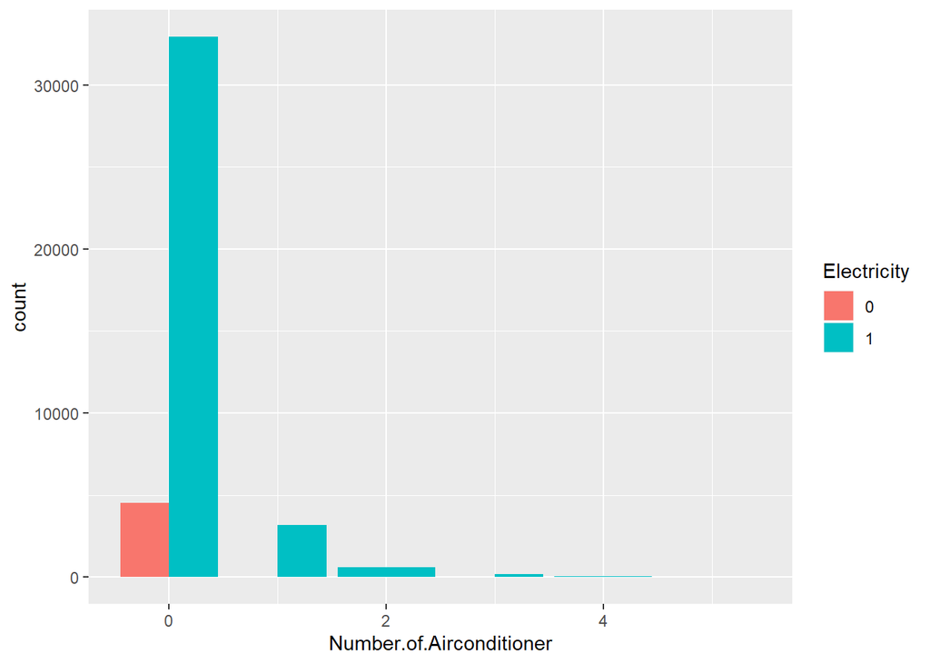

```r
ggplot(datos, aes(x=Number.of.Airconditioner,fill= Electricity)) + geom_bar(position = "dodge")
```

A la vista de la gráfica, se concluye que todos los usuarios que tienen aire acondicionado, tienen un 1 en Electricity, y que ningún usuario con un 0 tiene aire acondicionado, por lo que es posible afirmar que el 1 corresponde a tener electricidad, y el 0 a no tenerla.

Para clarificar, será categorizada con valores de “Si” y “No”, que sustituirán a los unos y ceros, respectivamente.

```r
# Sustitución de 0/1 por No/Si
datos$Electricity<-fct_recode(datos$Electricity,Si='1',No='0')
```

El último grupo de variables, corresponde al número de bienes adquiridos. Dichas variables son marcadas como numéricas, pero sus rangos son muy reducidos con respecto a las demás numéricas. Se inspecciona más a fondo estas variables viendo sus principales estadísticos:

```r
#---------------------------------------------------------------------------------------------------------------------------------------------
kable(c(summary(datos$Number.of.bedrooms)),caption="Summary de Number.of.bedrooms") %>%
  kable_styling() %>%
  scroll_box(width = "100%", height = "100%")
```

Summary de Number.of.bedrooms

|  | x |
| --- | --- |
| Min. | 0.000000 |
| 1st Qu. | 1.000000 |
| Median | 2.000000 |
| Mean | 1.788008 |
| 3rd Qu. | 2.000000 |
| Max. | 9.000000 |

```r
#---------------------------------------------------------------------------------------------------------------------------------------------
kable(c(summary(datos$Number.of.Refrigerator.Freezer)),caption="Summary de Number.of.Refrigerator.Freezer") %>%
  kable_styling() %>%
  scroll_box(width = "100%", height = "100%")
```

Summary de Number.of.Refrigerator.Freezer

|  | x |
| --- | --- |
| Min. | 0.0000000 |
| 1st Qu. | 0.0000000 |
| Median | 0.0000000 |
| Mean | 0.3941845 |
| 3rd Qu. | 1.0000000 |
| Max. | 5.0000000 |

```r
#---------------------------------------------------------------------------------------------------------------------------------------------
kable(c(summary(datos$Number.of.Washing.Machine)),caption="Summary de Number.of.Washing.Machine") %>%
  kable_styling() %>%
  scroll_box(width = "100%", height = "100%")
```

Summary de Number.of.Washing.Machine

|  | x |
| --- | --- |
| Min. | 0.0000000 |
| 1st Qu. | 0.0000000 |
| Median | 0.0000000 |
| Mean | 0.3198055 |
| 3rd Qu. | 1.0000000 |
| Max. | 3.0000000 |

```r
#---------------------------------------------------------------------------------------------------------------------------------------------
kable(c(summary(datos$Number.of.Airconditioner)),caption="Summary de Number.of.Airconditioner") %>%
  kable_styling() %>%
  scroll_box(width = "100%", height = "100%")
```

Summary de Number.of.Airconditioner

|  | x |
| --- | --- |
| Min. | 0.0000000 |
| 1st Qu. | 0.0000000 |
| Median | 0.0000000 |
| Mean | 0.1298142 |
| 3rd Qu. | 0.0000000 |
| Max. | 5.0000000 |

```r
#---------------------------------------------------------------------------------------------------------------------------------------------
kable(c(summary(datos$Number.of.Car..Jeep..Van)),caption="Summary de Number.of.Car..Jeep..Van") %>%
  kable_styling() %>%
  scroll_box(width = "100%", height = "100%")
```

Summary de Number.of.Car..Jeep..Van

|  | x |
| --- | --- |
| Min. | 0.0000000 |
| 1st Qu. | 0.0000000 |
| Median | 0.0000000 |
| Mean | 0.0812151 |
| 3rd Qu. | 0.0000000 |
| Max. | 5.0000000 |

```r
#---------------------------------------------------------------------------------------------------------------------------------------------
kable(c(summary(datos$Number.of.CD.VCD.DVD)),caption="Summary de Number.of.CD.VCD.DVD") %>%
  kable_styling() %>%
  scroll_box(width = "100%", height = "100%")
```

Summary de Number.of.CD.VCD.DVD

|  | x |
| --- | --- |
| Min. | 0.0000000 |
| 1st Qu. | 0.0000000 |
| Median | 0.0000000 |
| Mean | 0.4352253 |
| 3rd Qu. | 1.0000000 |
| Max. | 5.0000000 |

```r
#---------------------------------------------------------------------------------------------------------------------------------------------
kable(c(summary(datos$Number.of.Cellular.phone)),caption="Summary de Number.of.Cellular.phone") %>%
  kable_styling() %>%
  scroll_box(width = "100%", height = "100%")
```

Summary de Number.of.Cellular.phone

|  | x |
| --- | --- |
| Min. | 0.000000 |
| 1st Qu. | 1.000000 |
| Median | 2.000000 |
| Mean | 1.905739 |
| 3rd Qu. | 3.000000 |
| Max. | 10.000000 |

```r
#---------------------------------------------------------------------------------------------------------------------------------------------
kable(c(summary(datos$Number.of.Component.Stereo.set)),caption="Summary de Number.of.Component.Stereo.set") %>%
  kable_styling() %>%
  scroll_box(width = "100%", height = "100%")
```

Summary de Number.of.Component.Stereo.set

|  | x |
| --- | --- |
| Min. | 0.0000000 |
| 1st Qu. | 0.0000000 |
| Median | 0.0000000 |
| Mean | 0.1621413 |
| 3rd Qu. | 0.0000000 |
| Max. | 5.0000000 |

```r
#---------------------------------------------------------------------------------------------------------------------------------------------
kable(c(summary(datos$Number.of.Landline.wireless.telephones)),caption="Summary de Number.of.Landline.wireless.telephones") %>%
  kable_styling() %>%
  scroll_box(width = "100%", height = "100%")
```

Summary de Number.of.Landline.wireless.telephones

|  | x |
| --- | --- |
| Min. | 0.0000000 |
| 1st Qu. | 0.0000000 |
| Median | 0.0000000 |
| Mean | 0.0606104 |
| 3rd Qu. | 0.0000000 |
| Max. | 4.0000000 |

```r
#---------------------------------------------------------------------------------------------------------------------------------------------
kable(c(summary(datos$Number.of.Personal.Computer)),caption="Summary de Number.of.Personal.Computer") %>%
  kable_styling() %>%
  scroll_box(width = "100%", height = "100%")
```

Summary de Number.of.Personal.Computer

|  | x |
| --- | --- |
| Min. | 0.0000000 |
| 1st Qu. | 0.0000000 |
| Median | 0.0000000 |
| Mean | 0.3150154 |
| 3rd Qu. | 0.0000000 |
| Max. | 6.0000000 |

```r
#---------------------------------------------------------------------------------------------------------------------------------------------
kable(c(summary(datos$Number.of.Motorcycle.Tricycle)),caption="Summary de Number.of.Motorcycle.Tricycle") %>%
  kable_styling() %>%
  scroll_box(width = "100%", height = "100%")
```

Summary de Number.of.Motorcycle.Tricycle

|  | x |
| --- | --- |
| Min. | 0.0000000 |
| 1st Qu. | 0.0000000 |
| Median | 0.0000000 |
| Mean | 0.2898854 |
| 3rd Qu. | 0.0000000 |
| Max. | 5.0000000 |

```r
#---------------------------------------------------------------------------------------------------------------------------------------------
kable(c(summary(datos$Number.of.Stove.with.Oven.Gas.Range)),caption="Summary de Number.of.Stove.with.Oven.Gas.Range") %>%
  kable_styling() %>%
  scroll_box(width = "100%", height = "100%")
```

Summary de Number.of.Stove.with.Oven.Gas.Range

|  | x |
| --- | --- |
| Min. | 0.0000000 |
| 1st Qu. | 0.0000000 |
| Median | 0.0000000 |
| Mean | 0.1350376 |
| 3rd Qu. | 0.0000000 |
| Max. | 3.0000000 |

```r
#---------------------------------------------------------------------------------------------------------------------------------------------
kable(c(summary(datos$Number.of.Television)),caption="Summary de Number.of.Television") %>%
  kable_styling() %>%
  scroll_box(width = "100%", height = "100%")
```

Summary de Number.of.Television

|  | x |
| --- | --- |
| Min. | 0.0000000 |
| 1st Qu. | 0.0000000 |
| Median | 1.0000000 |
| Mean | 0.8568746 |
| 3rd Qu. | 1.0000000 |
| Max. | 6.0000000 |

```r
#---------------------------------------------------------------------------------------------------------------------------------------------
kable(c(summary(datos$Number.of.Motorized.Banca)),caption="Summary de Number.of.Motorized.Banca") %>%
  kable_styling() %>%
  scroll_box(width = "100%", height = "100%")
```

Summary de Number.of.Motorized.Banca

|  | x |
| --- | --- |
| Min. | 0.0000000 |
| 1st Qu. | 0.0000000 |
| Median | 0.0000000 |
| Mean | 0.0131186 |
| 3rd Qu. | 0.0000000 |
| Max. | 3.0000000 |

```r
#---------------------------------------------------------------------------------------------------------------------------------------------
```

Una vez están los datos ordenados, y debido a que el volumen de la muestra inicial podría ser un problema al tratar con ellos, se procede a realizar un muestreo de 10000 observaciones con muestreo aleatorio simple, fijando una semilla aleatoria.

Se divide la muestra de 10000 observaciones en dos conjuntos: uno de train y otro de test/validación (70%-30%). Se trabajará con el conjunto de train, mientras que el de test será reservado para la parte final (evaluación del modelo).

```r
# ----- Creación de una muestra del conjunto inicial de datos con muestreo aleatorio simple sin reemplazamiento -----

set.seed(300)
datos_s <- datos %>%
  sample_n(size=10000,replace=FALSE)

# División de la muestra de 10000 observaciones en dos conjuntos: uno de train y otro de test (70%-30%)

training <- createDataPartition(pull(datos_s, Total.Household.Income ),
                                p = 0.7, list = FALSE, times = 1)

datos_training <- slice(datos_s, training)
datos_testing <- slice(datos_s, -training)

var_train_cat <- datos_training%>%select_if(is.factor)
var_train_num <- datos_training%>%select_if(is.numeric)
```

### 4.2. Análisis variables cualitativas

Para estudiar más a fondo las variables cualitativas, es conveniente ver sus frecuencias absolutas, una a una, con ayuda de la función `table()`

Region:

```r
# ----- Frecuencias absolutas y relativas ------

# Frecuencias absolutas - función table() (tabla de contingencia)

table(var_train_cat$Region)
```

```
##
##                      ARMM                       CAR                    Caraga
##                       375                       299                       299
##         I - Ilocos Region       II - Cagayan Valley       III - Central Luzon
##                       401                       367                       532
##          IVA - CALABARZON            IVB - MIMAROPA IX - Zasmboanga Peninsula
##                       658                       193                       319
##                       NCR          V - Bicol Region      VI - Western Visayas
##                       724                       412                       497
##     VII - Central Visayas    VIII - Eastern Visayas     X - Northern Mindanao
##                       416                       397                       296
##         XI - Davao Region        XII - SOCCSKSARGEN
##                       432                       383
```

Main.Source.of.Income

```r
table(var_train_cat$Main.Source.of.Income)
```

```
##
##    Other sources of Income Enterpreneurial Activities
##                       1790                       1771
##              Wage/Salaries
##                       3439
```

Household.Head.Job.or.Business.Indicator

```r
table(var_train_cat$Household.Head.Job.or.Business.Indicator)
```

```
##
##   No Job/Business With Job/Business
##              1241              5759
```

Household.Head.Sex

```r
table(var_train_cat$Household.Head.Sex)
```

```
##
## Female   Male
##   1513   5487
```

Household.Head.Marital.Status

```r
table(var_train_cat$Household.Head.Marital.Status)
```

```
##
##             Single            Widowed           Annulled Divorced/Separated
##                319               1143                  4                223
##            Married
##               5311
```

Household.Head.Job.or.Business.Indicator

```r
table(var_train_cat$Household.Head.Job.or.Business.Indicator)
```

```
##
##   No Job/Business With Job/Business
##              1241              5759
```

Household.Head.Class.of.Worker

```r
table(var_train_cat$Household.Head.Class.of.Worker)
```

```
##
## Worked without pay in own family-operated farm or business
##                                                         50
##           Employer in own family-operated farm or business
##                                                        434
##    Worked with pay in own family-operated farm or business
##                                                          4
##                          Self-employed wihout any employee
##                                                       2304
##                               Worked for private household
##                                                        139
##                           Worked for private establishment
##                                                       2339
##               Worked for government/government corporation
##                                                        489
```

Type.of.Household

```r
table(var_train_cat$Type.of.Household)
```

```
##
##                          Single Family Two or More Nonrelated Persons/Members
##                                   4790                                     24
##                        Extended Family
##                                   2186
```

Type.of.Building.House

```r
table(var_train_cat$Type.of.Building.House)
```

```
##
##       Other building unit (e.g. cave, boat)
##                                           0
##                Institutional living quarter
##                                           2
## Commercial/industrial/agricultural building
##                                           7
##                                Single house
##                                        6584
##                                      Duplex
##                                         173
##                      Multi-unit residential
##                                         234
```

Type.of.Roof

```r
table(var_train_cat$Type.of.Roof)
```

```
##
##                                           Salvaged/makeshift materials
##                                                                     32
##                                     Light material (cogon,nipa,anahaw)
##                                                                    845
##                             Mixed but predominantly salvaged materials
##                                                                     11
##                                Mixed but predominantly light materials
##                                                                    133
##                               Mixed but predominantly strong materials
##                                                                    345
## Strong material(galvanized,iron,al,tile,concrete,brick,stone,asbestos)
##                                                                   5633
```

Type.of.Walls

```r
table(var_train_cat$Type.of.Walls)
```

```
##
##     Salvaged   Very Light        Light       Strong Quite Strong
##           81          258         1366         4701          590
```

Tenure.Status

```r
table(var_train_cat$Tenure.Status)
```

```
##
##    Own house, rent-free lot with consent of owner
##                                              1005
## Own house, rent-free lot without consent of owner
##                                               151
##                               Own house, rent lot
##                                                81
##     Own or owner-like possession of house and lot
##                                              5011
##     Rent-free house and lot with consent of owner
##                                               336
##  Rent-free house and lot without consent of owner
##                                                20
##                     Rent house/room including lot
##                                               389
```

Toilet.Facilities

```r
table(var_train_cat$Toilet.Facilities)
```

```
##
##                                                           None
##                                                            255
##                                                         Others
##                                                             65
##                                                       Open pit
##                                                            206
##                                                     Closed pit
##                                                            361
##    Water-sealed, other depository, shared with other household
##                                                            133
##  Water-sealed, other depository, used exclusively by household
##                                                            428
##   Water-sealed, sewer septic tank, shared with other household
##                                                            646
## Water-sealed, sewer septic tank, used exclusively by household
##                                                           4906
```

Electricity

```r
table(var_train_cat$Electricity)
```

```
##
##   No   Si
##  753 6247
```

Main.Source.of.Water.Supply

```r
table(var_train_cat$Main.Source.of.Water.Supply)
```

```
##
##                                  Others                                Dug well
##                                      16                                     663
##            Lake, river, rain and others  Unprotected spring, river, stream, etc
##                                      81                                     105
##    Protected spring, river, stream, etc                Tubed/piped shallow well
##                                     459                                     251
##           Shared, tubed/piped deep well          Own use, tubed/piped deep well
##                                    1012                                     775
##                                 Peddler  Shared, faucet, community water system
##                                     147                                     769
## Own use, faucet, community water system
##                                    2722
```

Number.of.Motorcycle.Tricycle

```r
table(var_train_cat$Number.of.Motorcycle.Tricycle)
```

```
## < table of extent 0 >
```

Household.Head.Highest.Grade.Completed

```r
table(var_train_cat$Household.Head.Highest.Grade.Completed)
```

```
##
##                                                                                                                                                                         Agriculture, Forestry, and Fishery Programs
##                                                                                                                                                                                                                  40
##                                                                                                                                                                                  Architecture and Building Programs
##                                                                                                                                                                                                                   6
##                                                                                                                                                                                                       Arts Programs
##                                                                                                                                                                                                                   4
##                                                                                                                                                                                                      Basic Programs
##                                                                                                                                                                                                                   6
##                                                                                                                                                                                Business and Administration Programs
##                                                                                                                                                                                                                 212
##                                                                                                                                                                           Computing/Information Technology Programs
##                                                                                                                                                                                                                  51
##                                                                                                                                                                                                 Elementary Graduate
##                                                                                                                                                                                                                1261
##                                                                                                                                                                         Engineering and Engineering trades Programs
##                                                                                                                                                                                                                  81
##                                                                                                                                                                         Engineering and Engineering Trades Programs
##                                                                                                                                                                                                                 147
##                                                                                                                                                                                   Environmental Protection Programs
##                                                                                                                                                                                                                   2
##                                                                                                                                                                                                  First Year College
##                                                                                                                                                                                                                 145
##                                                                                                                                                                                              First Year High School
##                                                                                                                                                                                                                 209
##                                                                                                                                                                                           First Year Post Secondary
```

[output cut: 67 more lines]

Seguidamente, serán visualizadas las frecuencias relativas, esta vez utilizando la función `prop.table()`

Region:

```r
# ----- Frecuencias absolutas y relativas ------

# Frecuencias relativas - función prop.table()

prop.table(table(var_train_cat$Region))
```

```
##
##                      ARMM                       CAR                    Caraga
##                0.05357143                0.04271429                0.04271429
##         I - Ilocos Region       II - Cagayan Valley       III - Central Luzon
##                0.05728571                0.05242857                0.07600000
##          IVA - CALABARZON            IVB - MIMAROPA IX - Zasmboanga Peninsula
##                0.09400000                0.02757143                0.04557143
##                       NCR          V - Bicol Region      VI - Western Visayas
##                0.10342857                0.05885714                0.07100000
##     VII - Central Visayas    VIII - Eastern Visayas     X - Northern Mindanao
##                0.05942857                0.05671429                0.04228571
##         XI - Davao Region        XII - SOCCSKSARGEN
##                0.06171429                0.05471429
```

Main.Source.of.Income

```r
prop.table(table(var_train_cat$Main.Source.of.Income))
```

```
##
##    Other sources of Income Enterpreneurial Activities
##                  0.2557143                  0.2530000
##              Wage/Salaries
##                  0.4912857
```

Household.Head.Job.or.Business.Indicator

```r
prop.table(table(var_train_cat$Household.Head.Job.or.Business.Indicator))
```

```
##
##   No Job/Business With Job/Business
##         0.1772857         0.8227143
```

Household.Head.Sex

```r
prop.table(table(var_train_cat$Household.Head.Sex))
```

```
##
##    Female      Male
## 0.2161429 0.7838571
```

Household.Head.Marital.Status

```r
prop.table(table(var_train_cat$Household.Head.Marital.Status))
```

```
##
##             Single            Widowed           Annulled Divorced/Separated
##       0.0455714286       0.1632857143       0.0005714286       0.0318571429
##            Married
##       0.7587142857
```

Household.Head.Job.or.Business.Indicator

```r
prop.table(table(var_train_cat$Household.Head.Job.or.Business.Indicator))
```

```
##
##   No Job/Business With Job/Business
##         0.1772857         0.8227143
```

Household.Head.Class.of.Worker

```r
prop.table(table(var_train_cat$Household.Head.Class.of.Worker))
```

```
##
## Worked without pay in own family-operated farm or business
##                                                0.008682063
##           Employer in own family-operated farm or business
##                                                0.075360306
##    Worked with pay in own family-operated farm or business
##                                                0.000694565
##                          Self-employed wihout any employee
##                                                0.400069457
##                               Worked for private household
##                                                0.024136135
##                           Worked for private establishment
##                                                0.406146901
##               Worked for government/government corporation
##                                                0.084910575
```

Type.of.Household

```r
prop.table(table(var_train_cat$Type.of.Household))
```

```
##
##                          Single Family Two or More Nonrelated Persons/Members
##                            0.684285714                            0.003428571
##                        Extended Family
##                            0.312285714
```

Type.of.Building.House

```r
prop.table(table(var_train_cat$Type.of.Building.House))
```

```
##
##       Other building unit (e.g. cave, boat)
##                                0.0000000000
##                Institutional living quarter
##                                0.0002857143
## Commercial/industrial/agricultural building
##                                0.0010000000
##                                Single house
##                                0.9405714286
##                                      Duplex
##                                0.0247142857
##                      Multi-unit residential
##                                0.0334285714
```

Type.of.Roof

```r
prop.table(table(var_train_cat$Type.of.Roof))
```

```
##
##                                           Salvaged/makeshift materials
##                                                            0.004572082
##                                     Light material (cogon,nipa,anahaw)
##                                                            0.120731533
##                             Mixed but predominantly salvaged materials
##                                                            0.001571653
##                                Mixed but predominantly light materials
##                                                            0.019002715
##                               Mixed but predominantly strong materials
##                                                            0.049292756
## Strong material(galvanized,iron,al,tile,concrete,brick,stone,asbestos)
##                                                            0.804829261
```

Type.of.Walls

```r
prop.table(table(var_train_cat$Type.of.Walls))
```

```
##
##     Salvaged   Very Light        Light       Strong Quite Strong
##   0.01157804   0.03687822   0.19525443   0.67195540   0.08433391
```

Tenure.Status

```r
prop.table(table(var_train_cat$Tenure.Status))
```

```
##
##    Own house, rent-free lot with consent of owner
##                                       0.143715144
## Own house, rent-free lot without consent of owner
##                                       0.021593022
##                               Own house, rent lot
##                                       0.011583012
##     Own or owner-like possession of house and lot
##                                       0.716573717
##     Rent-free house and lot with consent of owner
##                                       0.048048048
##  Rent-free house and lot without consent of owner
##                                       0.002860003
##                     Rent house/room including lot
##                                       0.055627056
```

Toilet.Facilities

```r
prop.table(table(var_train_cat$Toilet.Facilities))
```

```
##
##                                                           None
##                                                    0.036428571
##                                                         Others
##                                                    0.009285714
##                                                       Open pit
##                                                    0.029428571
##                                                     Closed pit
##                                                    0.051571429
##    Water-sealed, other depository, shared with other household
##                                                    0.019000000
##  Water-sealed, other depository, used exclusively by household
##                                                    0.061142857
##   Water-sealed, sewer septic tank, shared with other household
##                                                    0.092285714
## Water-sealed, sewer septic tank, used exclusively by household
##                                                    0.700857143
```

Electricity

```r
prop.table(table(var_train_cat$Electricity))
```

```
##
##        No        Si
## 0.1075714 0.8924286
```

Main.Source.of.Water.Supply

```r
prop.table(table(var_train_cat$Main.Source.of.Water.Supply))
```

```
##
##                                  Others                                Dug well
##                             0.002285714                             0.094714286
##            Lake, river, rain and others  Unprotected spring, river, stream, etc
##                             0.011571429                             0.015000000
##    Protected spring, river, stream, etc                Tubed/piped shallow well
##                             0.065571429                             0.035857143
##           Shared, tubed/piped deep well          Own use, tubed/piped deep well
##                             0.144571429                             0.110714286
##                                 Peddler  Shared, faucet, community water system
##                             0.021000000                             0.109857143
## Own use, faucet, community water system
##                             0.388857143
```

Number.of.Motorcycle.Tricycle

```r
prop.table(table(var_train_cat$Number.of.Motorcycle.Tricycle))
```

```
## numeric(0)
```

Household.Head.Highest.Grade.Completed

```r
prop.table(table(var_train_cat$Household.Head.Highest.Grade.Completed))
```

```
##
##                                                                                                                                                                         Agriculture, Forestry, and Fishery Programs
##                                                                                                                                                                                                        0.0057142857
##                                                                                                                                                                                  Architecture and Building Programs
##                                                                                                                                                                                                        0.0008571429
##                                                                                                                                                                                                       Arts Programs
##                                                                                                                                                                                                        0.0005714286
##                                                                                                                                                                                                      Basic Programs
##                                                                                                                                                                                                        0.0008571429
##                                                                                                                                                                                Business and Administration Programs
##                                                                                                                                                                                                        0.0302857143
##                                                                                                                                                                           Computing/Information Technology Programs
##                                                                                                                                                                                                        0.0072857143
##                                                                                                                                                                                                 Elementary Graduate
##                                                                                                                                                                                                        0.1801428571
##                                                                                                                                                                         Engineering and Engineering trades Programs
##                                                                                                                                                                                                        0.0115714286
##                                                                                                                                                                         Engineering and Engineering Trades Programs
##                                                                                                                                                                                                        0.0210000000
##                                                                                                                                                                                   Environmental Protection Programs
##                                                                                                                                                                                                        0.0002857143
##                                                                                                                                                                                                  First Year College
##                                                                                                                                                                                                        0.0207142857
##                                                                                                                                                                                              First Year High School
##                                                                                                                                                                                                        0.0298571429
##                                                                                                                                                                                           First Year Post Secondary
```

[output cut: 67 more lines]

Al examinar las visualizaciones, la variable categórica `electricity` llama la atención. Se procede a comparar la variable electricity por regiones, ya que puede dar una idea acerca de en qué regiones puede existir mayor nivel de pobreza. Esto se realiza mediante la función `cross-table`, que nos mostrará las frecuencias absolutas, relativas en relación a la fila, frecuencias relativas en relación a la columna y frecuencias relativas globales:

```r
CrossTable(var_train_cat$Region, var_train_cat$Electricity, prop.chisq = FALSE)
```

```
##
##
##    Cell Contents
## |-------------------------|
## |                       N |
## |           N / Row Total |
## |           N / Col Total |
## |         N / Table Total |
## |-------------------------|
##
##
## Total Observations in Table:  7000
##
##
##                           | var_train_cat$Electricity
##      var_train_cat$Region |        No |        Si | Row Total |
## --------------------------|-----------|-----------|-----------|
##                      ARMM |       162 |       213 |       375 |
##                           |     0.432 |     0.568 |     0.054 |
##                           |     0.215 |     0.034 |           |
##                           |     0.023 |     0.030 |           |
## --------------------------|-----------|-----------|-----------|
##                       CAR |        18 |       281 |       299 |
##                           |     0.060 |     0.940 |     0.043 |
##                           |     0.024 |     0.045 |           |
##                           |     0.003 |     0.040 |           |
## --------------------------|-----------|-----------|-----------|
##                    Caraga |        24 |       275 |       299 |
##                           |     0.080 |     0.920 |     0.043 |
##                           |     0.032 |     0.044 |           |
##                           |     0.003 |     0.039 |           |
## --------------------------|-----------|-----------|-----------|
##         I - Ilocos Region |        20 |       381 |       401 |
##                           |     0.050 |     0.950 |     0.057 |
##                           |     0.027 |     0.061 |           |
##                           |     0.003 |     0.054 |           |
## --------------------------|-----------|-----------|-----------|
##       II - Cagayan Valley |        23 |       344 |       367 |
##                           |     0.063 |     0.937 |     0.052 |
##                           |     0.031 |     0.055 |           |
```

[output cut: 52 more lines]

```
##         XI - Davao Region |        48 |       384 |       432 |
##                           |     0.111 |     0.889 |     0.062 |
##                           |     0.064 |     0.061 |           |
##                           |     0.007 |     0.055 |           |
## --------------------------|-----------|-----------|-----------|
##        XII - SOCCSKSARGEN |        65 |       318 |       383 |
##                           |     0.170 |     0.830 |     0.055 |
##                           |     0.086 |     0.051 |           |
##                           |     0.009 |     0.045 |           |
## --------------------------|-----------|-----------|-----------|
##              Column Total |       753 |      6247 |      7000 |
##                           |     0.108 |     0.892 |           |
## --------------------------|-----------|-----------|-----------|
##
##
```

Se incorpora al análisis una tercera variable que suscita interés en el estudio: la variable `Sex`, que indica el sexo de la persona que toma las decisiones en el hogar.

# Tabla de contingencia region-sexo:

```r
# ----- Estudio de frecuencias multidimensionales -----

# Análisis de la variable electricity/región/sexo

ftable(var_train_cat$Region, var_train_cat$Household.Head.Sex, var_train_cat$Electricity)
```

```
##                                    No  Si
##
##  ARMM                     Female    9  18
##                           Male    153 195
## CAR                       Female    1  65
##                           Male     17 216
## Caraga                    Female    4  46
##                           Male     20 229
## I - Ilocos Region         Female    7  97
##                           Male     13 284
## II - Cagayan Valley       Female    1  50
##                           Male     22 294
## III - Central Luzon       Female    4 124
##                           Male      9 395
## IVA - CALABARZON          Female    9 156
##                           Male     17 476
## IVB - MIMAROPA            Female    1  36
##                           Male     25 131
## IX - Zasmboanga Peninsula Female    7  51
##                           Male     46 215
## NCR                       Female    1 194
##                           Male      5 524
## V - Bicol Region          Female    8  86
##                           Male     39 279
## VI - Western Visayas      Female   14 106
##                           Male     53 324
## VII - Central Visayas     Female   10 106
##                           Male     37 263
## VIII - Eastern Visayas    Female    9  77
##                           Male     55 256
## X - Northern Mindanao     Female    8  53
##                           Male     36 199
## XI - Davao Region         Female   11  73
##                           Male     37 311
## XII - SOCCSKSARGEN        Female   11  60
##                           Male     54 258
```

Finalmente, se muestra una serie de visualizaciones de los datos mediante diagramas de barras:

# Gráficos EDA con variables cualitativas individuales

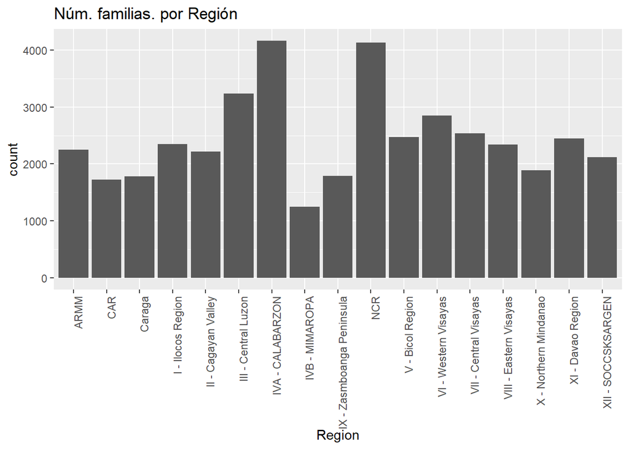

```r
# ----- Gráficos EDA con variables cualitativas individuales -----

ggplot(datos, aes(Region)) + geom_bar() + ggtitle("Núm. familias. por Región") + theme(axis.text.x = element_text(angle = 90, hjust = 1))
```

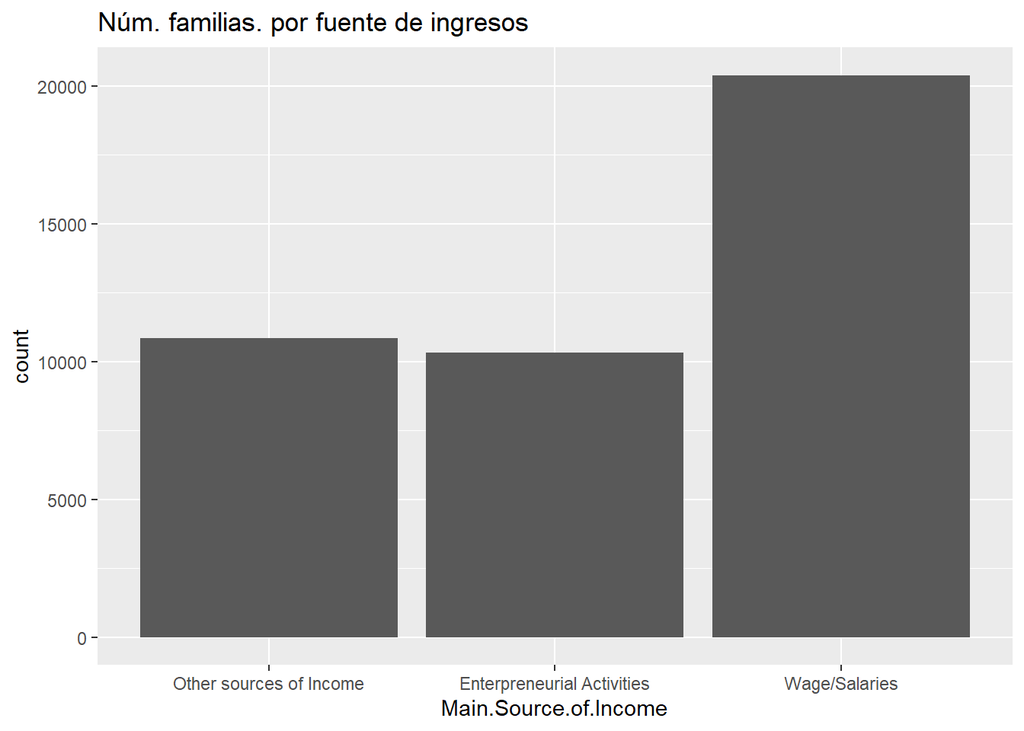

```r
ggplot(datos, aes(Main.Source.of.Income)) + geom_bar() + ggtitle("Núm. familias. por fuente de ingresos")
```

# Visualización de datos cualitativos

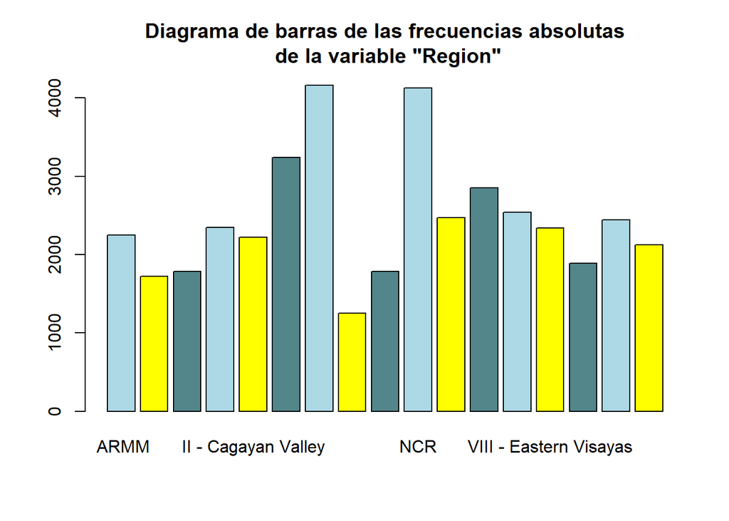

```r
# ----- Visualización de datos cualitativos -----

barplot(table(datos$Region), col = c("lightblue","yellow", "cadetblue4"),
        main = "Diagrama de barras de las frecuencias absolutas\n de la variable \"Region\"")
```

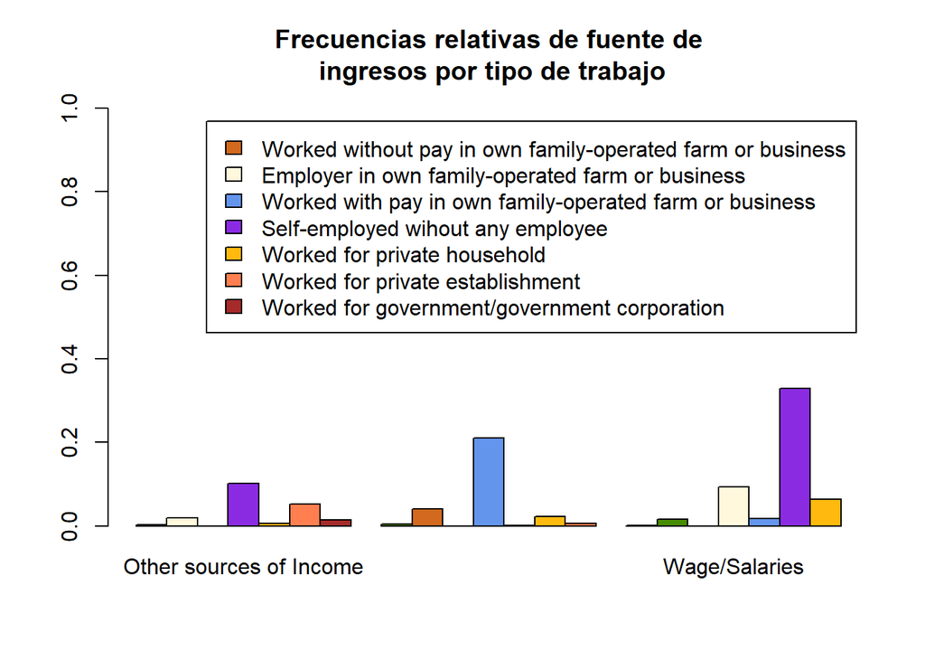

```r
barplot(prop.table(table(datos$Household.Head.Class.of.Worker,datos$Main.Source.of.Income)),
        beside = TRUE, col = c("chocolate","cornsilk1","cornflowerblue","blueviolet", "darkgoldenrod1", "coral", "brown", "chartreuse4"),
        legend.text = T, main = "Frecuencias relativas de fuente de\n ingresos por tipo de trabajo",
        ylim = c(0,1))
```

### 4.3. Análisis variables cuantitativas

Se dispone a ver la distribución y densidad de cada una de las variables cuantitativas sin transformar, es decir, las variables “en crudo”. De esta manera, se pretende identificar aquellas con los datos más sesgados, y poder observar las distribuciones y rangos que presentan. Se irán visualizando las distribuciones de las variables, agrupadas de 6 en 6 para facilitar la visualización.

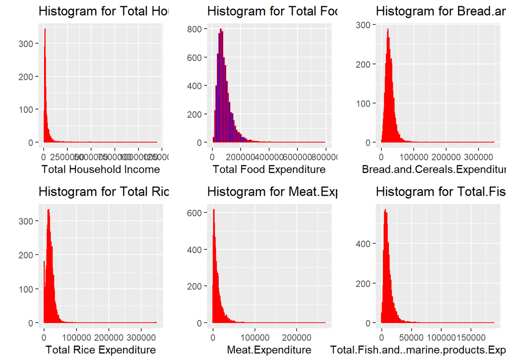

```r
# ----- Histograma de las variables cuantitativas sin transformar -----

# Primeras 6 variables

p1 <- qplot(var_train_num$Total.Household.Income,
      geom="histogram",
      binwidth = 10000,
      main = "Histogram for Total Household Income",
      xlab = "Total Household Income",
      fill=I("blue"),
      col=I("red"),
      xlim=c(10000,12000000))
p2 <- qplot(var_train_num$Total.Food.Expenditure,
      geom="histogram",
      binwidth = 10000,
      main = "Histogram for Total Food Expenditure",
      xlab = "Total Food Expenditure",
      fill=I("blue"),
      col=I("red"),
      xlim=c(2000,800000))
p3 <- qplot(var_train_num$Bread.and.Cereals.Expenditure,
      geom="histogram",
      binwidth = 1000,
      main = "Histogram for Bread.and.Cereals.Expenditure",
      xlab = "Bread.and.Cereals.Expenditure",
      fill=I("blue"),
      col=I("red"),
      xlim=c(-1000,350000))
p4 <- qplot(var_train_num$Total.Rice.Expenditure,
      geom="histogram",
      binwidth = 1000,
      main = "Histogram for Total Rice Expenditure",
      xlab = "Total Rice Expenditure",
      fill=I("blue"),
      col=I("red"),
      xlim=c(-1000,350000))
p5 <- qplot(var_train_num$Meat.Expenditure,
      geom="histogram",
      binwidth = 1000,
      main = "Histogram for Meat.Expenditure",
      xlab = "Meat.Expenditure",
      fill=I("blue"),
      col=I("red"),
      xlim=c(-1000,270000))
p6 <- qplot(var_train_num$Total.Fish.and..marine.products.Expenditure,
      geom="histogram",
      binwidth = 1000,
      main = "Histogram for Total.Fish.and..marine.products.Expenditure",
      xlab = "Total.Fish.and..marine.products.Expenditure",
      fill=I("blue"),
      col=I("red"),
      xlim=c(-1000,190000))

grid.arrange(p1,p2,p3,p4,p5,p6,nrow=2)
```

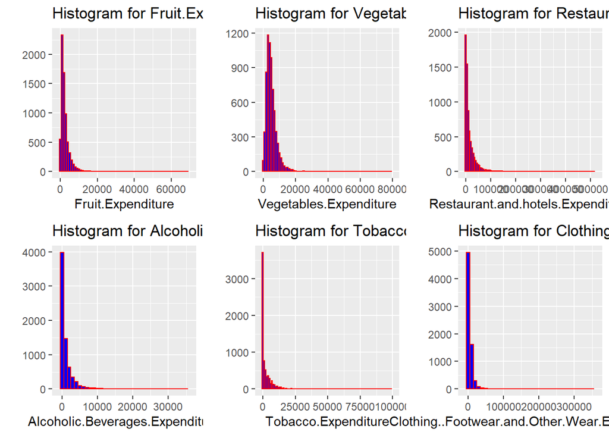

```r
# Siguientes 6 variables


d1 <- qplot(var_train_num$Fruit.Expenditure,
      geom="histogram",
      binwidth = 1000,
      main = "Histogram for Fruit.Expenditure",
      xlab = "Fruit.Expenditure",
      fill=I("blue"),
      col=I("red"),
      xlim=c(-1000,70000))
d2 <- qplot(var_train_num$Vegetables.Expenditure,
      geom="histogram",
      binwidth = 1000,
      main = "Histogram for Vegetables.Expenditure",
      xlab = "Vegetables.Expenditure",
      fill=I("blue"),
      col=I("red"),
      xlim=c(-1000,80000))
d3 <- qplot(var_train_num$Restaurant.and.hotels.Expenditure,
      geom="histogram",
      binwidth = 5000,
      main = "Histogram for Restaurant.and.hotels.Expenditure",
      xlab = "Restaurant.and.hotels.Expenditure",
      fill=I("blue"),
      col=I("red"),
      xlim=c(-5000,520000))
d4 <- qplot(var_train_num$Alcoholic.Beverages.Expenditure,
      geom="histogram",
      binwidth = 1000,
      main = "Histogram for Alcoholic.Beverages.Expenditure",
      xlab = "Alcoholic.Beverages.Expenditure",
      fill=I("blue"),
      col=I("red"),
      xlim=c(-1000,36000))
d5 <- qplot(var_train_num$Tobacco.Expenditure,
      geom="histogram",
      binwidth = 1000,
      main = "Histogram for Tobacco.Expenditure",
      xlab = "Tobacco.Expenditure",
      fill=I("blue"),
      col=I("red"),
      xlim=c(-1000,100000))
d6 <- qplot(var_train_num$Clothing..Footwear.and.Other.Wear.Expenditure,
      geom="histogram",
      binwidth = 10000,
      main = "Histogram for Clothing..Footwear.and.Other.Wear.Expenditure",
      xlab = "Clothing..Footwear.and.Other.Wear.Expenditure",
      fill=I("blue"),
      col=I("red"),
      xlim=c(-10000,360000))


grid.arrange(d1,d2,d3,d4,d5,d6,nrow=2)
```

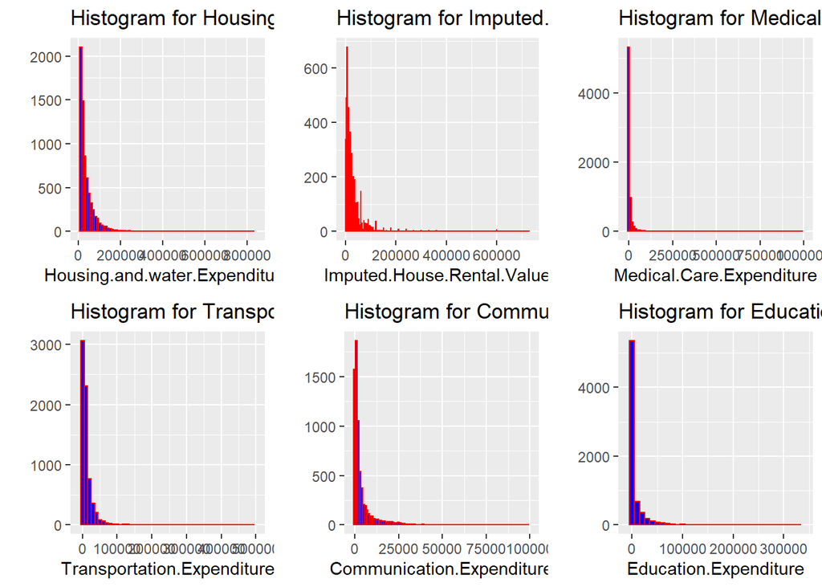

```r
# Siguientes 6 variables

h1 <- qplot(var_train_num$Housing.and.water.Expenditure,
      geom="histogram",
      binwidth = 10000,
      main = "Histogram for Housing.and.water.Expenditure",
      xlab = "Housing.and.water.Expenditure",
      fill=I("blue"),
      col=I("red"),
      xlim=c(2000,842000))
h2 <- qplot(var_train_num$Imputed.House.Rental.Value,
      geom="histogram",
      binwidth = 1000,
      main = "Histogram for Imputed.House.Rental.Value",
      xlab = "Imputed.House.Rental.Value",
      fill=I("blue"),
      col=I("red"),
      xlim=c(-1000,730000))
h3 <- qplot(var_train_num$Medical.Care.Expenditure,
      geom="histogram",
      binwidth = 10000,
      main = "Histogram for Medical.Care.Expenditure",
      xlab = "Medical.Care.Expenditure",
      fill=I("blue"),
      col=I("red"),
      xlim=c(-10000,1000000))
h4 <- qplot(var_train_num$Transportation.Expenditure,
      geom="histogram",
      binwidth = 10000,
      main = "Histogram for Transportation.Expenditure",
      xlab = "Transportation.Expenditure",
      fill=I("blue"),
      col=I("red"),
      xlim=c(-10000,500000))
h5 <- qplot(var_train_num$Communication.Expenditure,
      geom="histogram",
      binwidth = 1000,
      main = "Histogram for Communication.Expenditure",
      xlab = "Communication.Expenditure",
      fill=I("blue"),
      col=I("red"),
      xlim=c(-1000,100000))
h6 <- qplot(var_train_num$Education.Expenditure,
      geom="histogram",
      binwidth = 10000,
      main = "Histogram for Education.Expenditure",
      xlab = "Education.Expenditure",
      fill=I("blue"),
      col=I("red"),
      xlim=c(-10000,340000))

grid.arrange(h1,h2,h3,h4,h5,h6,nrow=2)
```

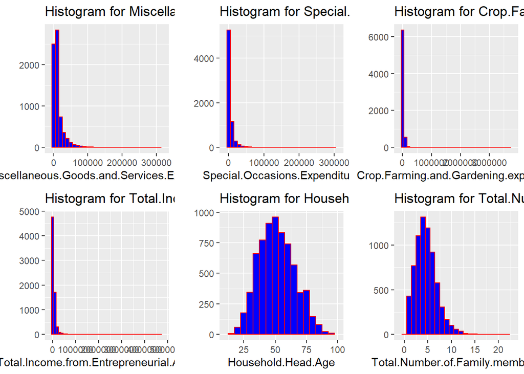

```r
# Siguientes 6 variables


s1 <- qplot(var_train_num$Miscellaneous.Goods.and.Services.Expenditure,
      geom="histogram",
      binwidth = 10000,
      main = "Histogram for Miscellaneous.Goods.and.Services.Expenditure",
      xlab = "Miscellaneous.Goods.and.Services.Expenditure",
      fill=I("blue"),
      col=I("red"),
      xlim=c(-10000,320000))
s2 <- qplot(var_train_num$Special.Occasions.Expenditure,
      geom="histogram",
      binwidth = 10000,
      main = "Histogram for Special.Occasions.Expenditure",
      xlab = "Special.Occasions.Expenditure",
      fill=I("blue"),
      col=I("red"),
      xlim=c(-10000,310000))
s3 <- qplot(var_train_num$Crop.Farming.and.Gardening.expenses,
      geom="histogram",
      binwidth = 100000,
      main = "Histogram for Crop.Farming.and.Gardening.expenses",
      xlab = "Crop.Farming.and.Gardening.expenses",
      fill=I("blue"),
      col=I("red"),
      xlim=c(-100000,3800000))
s4 <- qplot(var_train_num$Total.Income.from.Entrepreneurial.Acitivites,
      geom="histogram",
      binwidth = 100000,
      main = "Histogram for Total.Income.from.Entrepreneurial.Acitivites",
      xlab = "Total.Income.from.Entrepreneurial.Acitivites",
      fill=I("blue"),
      col=I("red"),
      xlim=c(-100000,4800000))
s5 <- qplot(var_train_num$Household.Head.Age,
      geom="histogram",
      binwidth = 5,
      main = "Histogram for Household.Head.Age",
      xlab = "Household.Head.Age",
      fill=I("blue"),
      col=I("red"),
      xlim=c(10,100))
s6 <- qplot(var_train_num$Total.Number.of.Family.members,
      geom="histogram",
      binwidth = 1,
      main = "Histogram for Total.Number.of.Family.members",
      xlab = "Total.Number.of.Family.members",
      fill=I("blue"),
      col=I("red"),
      xlim=c(-1,23))


grid.arrange(s1,s2,s3,s4,s5,s6,nrow=2)
```

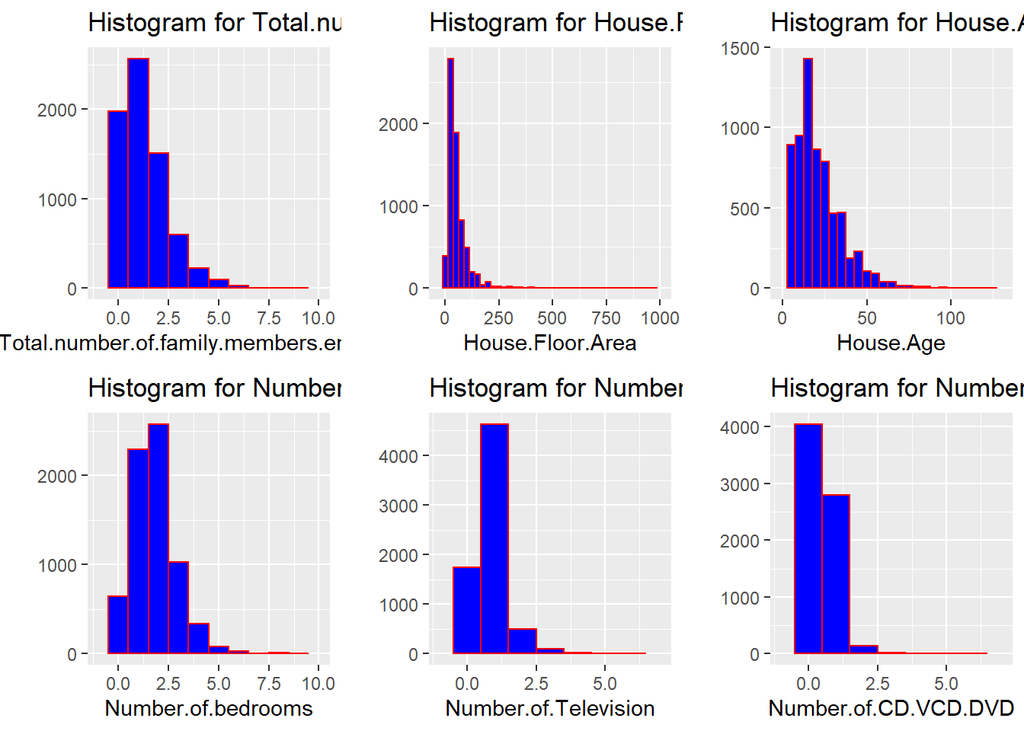

```r
# Otras 6 variables


g1 <- qplot(var_train_num$Total.number.of.family.members.employed,
      geom="histogram",
      binwidth = 1,
      main = "Histogram for Total.number.of.family.members.employed",
      xlab = "Total.number.of.family.members.employed",
      fill=I("blue"),
      col=I("red"),
      xlim=c(-1,10))
g2 <- qplot(var_train_num$House.Floor.Area,
      geom="histogram",
      binwidth = 25,
      main = "Histogram for House.Floor.Area",
      xlab = "House.Floor.Area",
      fill=I("blue"),
      col=I("red"),
      xlim=c(-25,1000))
g3 <- qplot(var_train_num$House.Age,
      geom="histogram",
      binwidth = 5,
      main = "Histogram for House.Age",
      xlab = "House.Age",
      fill=I("blue"),
      col=I("red"),
      xlim=c(-1,130))
g4 <- qplot(var_train_num$Number.of.bedrooms,
      geom="histogram",
      binwidth = 1,
      main = "Histogram for Number.of.bedrooms",
      xlab = "Number.of.bedrooms",
      fill=I("blue"),
      col=I("red"),
      xlim=c(-1,10))
g5 <- qplot(var_train_num$Number.of.Television,
      geom="histogram",
      binwidth = 1,
      main = "Histogram for Number.of.Television",
      xlab = "Number.of.Television",
      fill=I("blue"),
      col=I("red"),
      xlim=c(-1,7))
g6 <- qplot(var_train_num$Number.of.CD.VCD.DVD,
      geom="histogram",
      binwidth = 1,
      main = "Histogram for Number.of.CD.VCD.DVD",
      xlab = "Number.of.CD.VCD.DVD",
      fill=I("blue"),
      col=I("red"),
      xlim=c(-1,7))


grid.arrange(g1,g2,g3,g4,g5,g6,nrow=2)
```

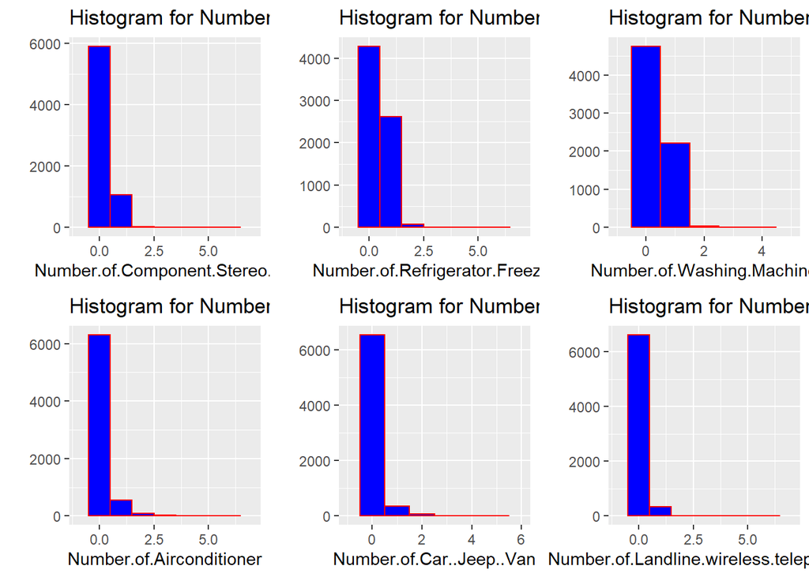

```r
# Siguientes 6 variables


o1 <- qplot(var_train_num$Number.of.Component.Stereo.set,
      geom="histogram",
      binwidth = 1,
      main = "Histogram for Number.of.Component.Stereo.set",
      xlab = "Number.of.Component.Stereo.set",
      fill=I("blue"),
      col=I("red"),
      xlim=c(-1,7))
o2 <- qplot(var_train_num$Number.of.Refrigerator.Freezer,
      geom="histogram",
      binwidth = 1,
      main = "Histogram for Number.of.Refrigerator.Freezer",
      xlab = "Number.of.Refrigerator.Freezer",
      fill=I("blue"),
      col=I("red"),
      xlim=c(-1,7))
o3 <- qplot(var_train_num$Number.of.Washing.Machine,
      geom="histogram",
      binwidth = 1,
      main = "Histogram for Number.of.Washing.Machine",
      xlab = "Number.of.Washing.Machine",
      fill=I("blue"),
      col=I("red"),
      xlim=c(-1,5))
o4 <- qplot(var_train_num$Number.of.Airconditioner,
      geom="histogram",
      binwidth = 1,
      main = "Histogram for Number.of.Airconditioner",
      xlab = "Number.of.Airconditioner",
      fill=I("blue"),
      col=I("red"),
      xlim=c(-1,7))
o5 <- qplot(var_train_num$Number.of.Car..Jeep..Van,
      geom="histogram",
      binwidth = 1,
      main = "Histogram for Number.of.Car..Jeep..Van",
      xlab = "Number.of.Car..Jeep..Van",
      fill=I("blue"),
      col=I("red"),
      xlim=c(-1,6))
o6 <- qplot(var_train_num$Number.of.Landline.wireless.telephones,
      geom="histogram",
      binwidth = 1,
      main = "Histogram for Number.of.Landline.wireless.telephones",
      xlab = "Number.of.Landline.wireless.telephones",
      fill=I("blue"),
      col=I("red"),
      xlim=c(-1,7))

grid.arrange(o1,o2,o3,o4,o5,o6,nrow=2)
```

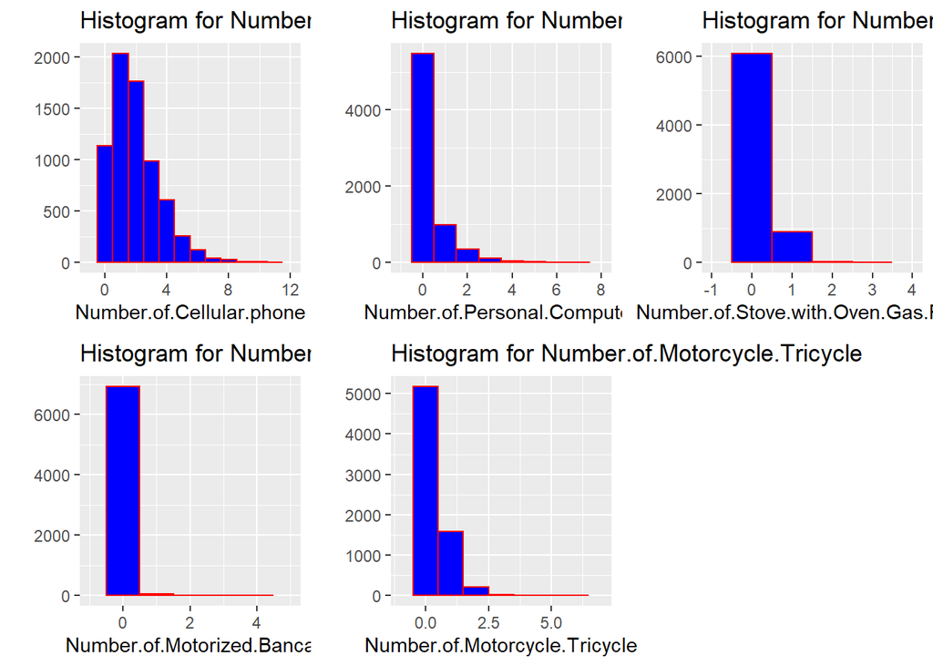

```r
# Últimas 5 variables


w1 <- qplot(var_train_num$Number.of.Cellular.phone,
      geom="histogram",
      binwidth = 1,
      main = "Histogram for Number.of.Cellular.phone",
      xlab = "Number.of.Cellular.phone",
      fill=I("blue"),
      col=I("red"),
      xlim=c(-1,12))

w2 <- qplot(var_train_num$Number.of.Personal.Computer,
      geom="histogram",
      binwidth = 1,
      main = "Histogram for Number.of.Personal.Computer",
      xlab = "Number.of.Personal.Computer",
      fill=I("blue"),
      col=I("red"),
      xlim=c(-1,8))
w3 <- qplot(var_train_num$Number.of.Stove.with.Oven.Gas.Range,
      geom="histogram",
      binwidth = 1,
      main = "Histogram for Number.of.Stove.with.Oven.Gas.Range",
      xlab = "Number.of.Stove.with.Oven.Gas.Range",
      fill=I("blue"),
      col=I("red"),
      xlim=c(-1,4))
w4 <- qplot(var_train_num$Number.of.Motorized.Banca,
      geom="histogram",
      binwidth = 1,
      main = "Histogram for Number.of.Motorized.Banca",
      xlab = "Number.of.Motorized.Banca",
      fill=I("blue"),
      col=I("red"),
      xlim=c(-1,5))
w5 <- qplot(var_train_num$Number.of.Motorcycle.Tricycle,
      geom="histogram",
      binwidth = 1,
      main = "Histogram for Number.of.Motorcycle.Tricycle",
      xlab = "Number.of.Motorcycle.Tricycle",
      fill=I("blue"),
      col=I("red"),
      xlim=c(-1,7))

grid.arrange(w1,w2,w3,w4,w5,nrow=2)
```

### 4.4. Representación datos cualitativos y cuantitativos

Para esta sección, han sido planteadas una serie de preguntas interesantes que pueden ser respondidas a través de visualizaciones:

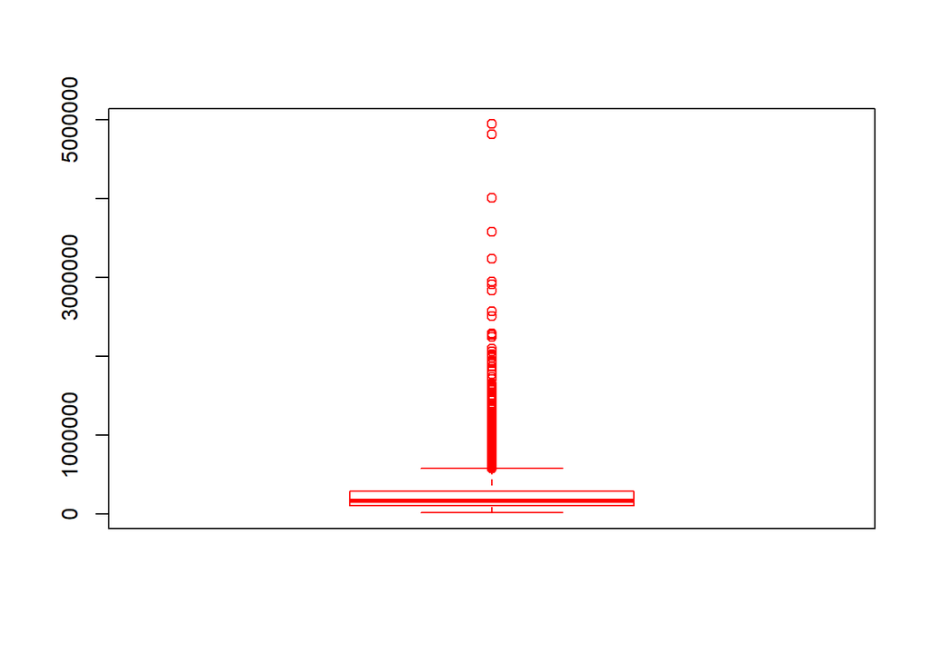

```r
grupo1 <- datos_training %>%
  filter(Total.Household.Income < 400000)

ceros_restaurant <- datos_training %>% filter(Restaurant.and.hotels.Expenditure < 1)

grupo2y3 <- datos_training %>%
  filter(Total.Household.Income >= 400000)

grupo2 <- grupo2y3 %>%
  filter(Total.Household.Income < 1000000)

grupo3 <- grupo2y3 %>%
  filter(Total.Household.Income >= 1000000)


boxplot(datos_training$Total.Household.Income,
        border = c("red"),
        caption="Diagrama de caja del conjunto de datos")
```

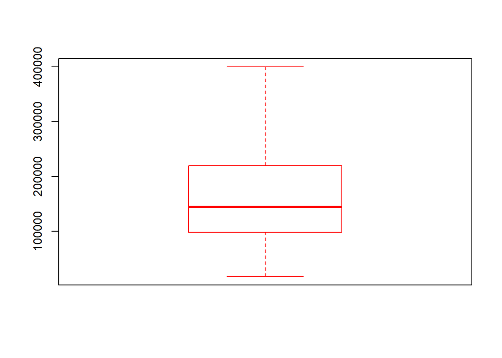

```r
boxplot(grupo1$Total.Household.Income,
        border = c("red"),
        caption="Diagrama de caja del grupo más desfavorecido económicamente")
```

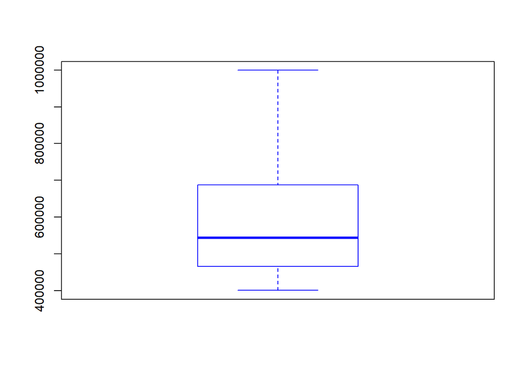

```r
boxplot(grupo2$Total.Household.Income,
        border = c("blue"),
        caption="Diagrama de caja del grupo con ingresos 'medios'")
```

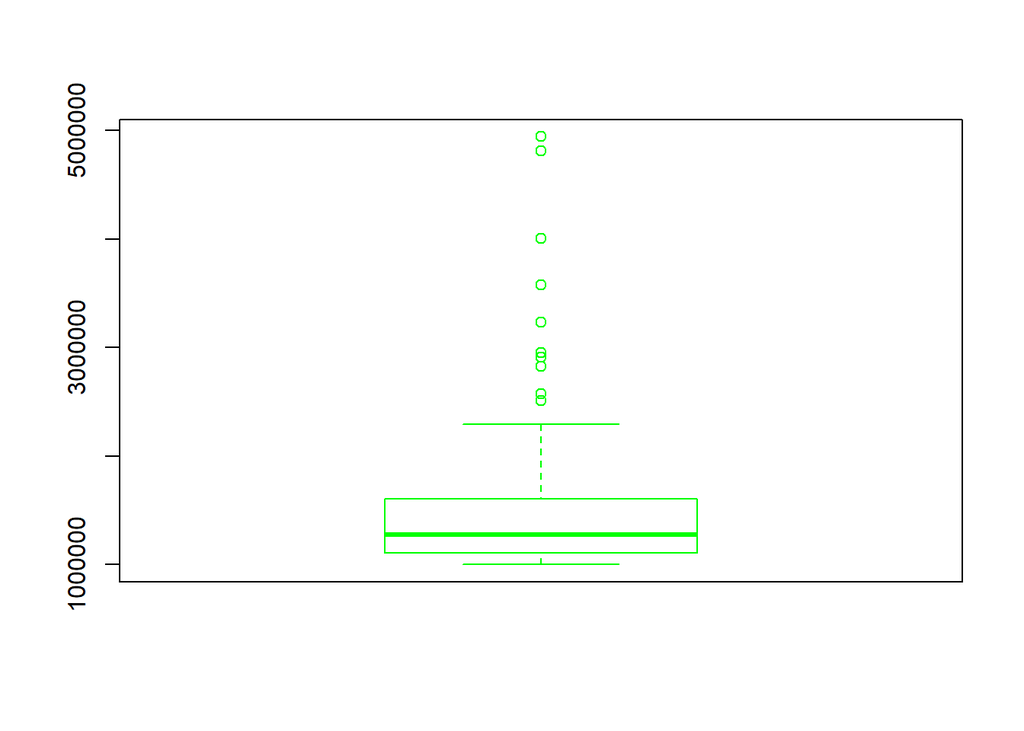

```r
boxplot(grupo3$Total.Household.Income,
        border = c("green"),
        caption="Diagrama de caja del grupo más favorecido económicamente")
```

- *Cuál es la relación entre el consumo de comida y ropa respecto a los ingresos familiares?*

Se decide filtrar por regiones y visualizar la cantidad de ingresos por familia a partir del tamaño de las burbujas.

# Bubble plot para ver la relación entre consumo de comida y de ropa respecto a los ingresos (tamaño de la burbuja) dividido por regiones (ciudades)

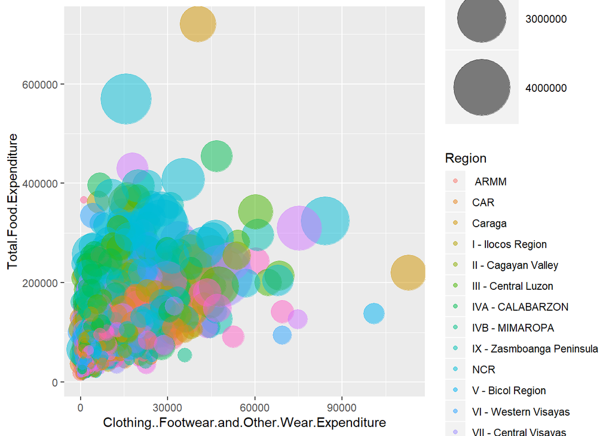

```r
# Bubble plot para ver la relación entre consumo de comida y de ropa respecto a los ingresos (tamaño de la burbuja) dividido por regiones (ciudades)

datos_training %>%
  ggplot(aes(x=Clothing..Footwear.and.Other.Wear.Expenditure, y=Total.Food.Expenditure, size = Total.Household.Income, color = Region, scientific=F)) +
    geom_point(alpha=0.5) +
    scale_size(range = c(.1, 24), name="Ingresos")
```

- *¿Cuáles son las profesiones más comunes de una familia Filipina?*

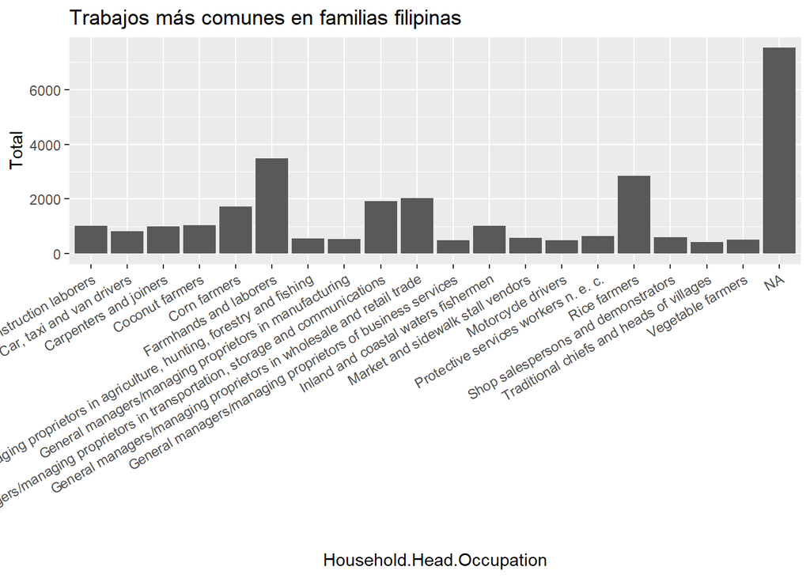

```r
# Profesiones más comúnes en Filipinas

by_common_jobs <- datos_occupation %>%
  group_by(Household.Head.Occupation) %>%
  summarise(Total = n()) %>%
  arrange(desc(Total)) %>%
  head(20) %>% ungroup()


ggplot(data = by_common_jobs) + geom_bar(mapping = aes(x = Household.Head.Occupation, y = Total), stat = "identity") + labs(title="Trabajos más comunes en familias filipinas") + theme(axis.text.x = element_text(angle = 30, hjust = 1))
```

- *¿Cuáles son las regiones de Filipinas con más gastos?*

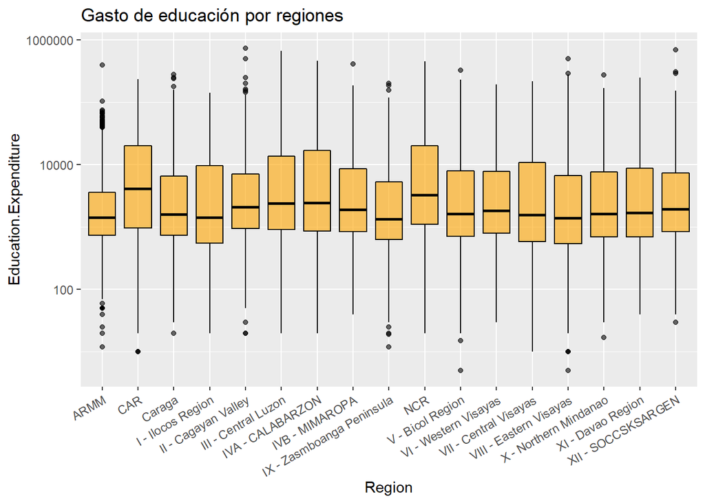

```r
# Región y gastos

by_region_educ <- datos_occupation %>%
  group_by(Region, Education.Expenditure, Housing.and.water.Expenditure) %>%
  summarise(Total = n()) %>%
  arrange(desc(Total)) %>% ungroup()


# Para ver el boxplot es necesario transformar la variable

ggplot(by_region_educ, aes(x=Region, y=Education.Expenditure)) + geom_boxplot(color="black", fill="orange", alpha = 0.6) + scale_y_log10() + labs(title="Gasto de educación por regiones") + theme(axis.text.x = element_text(angle = 30, hjust = 1))
```

## 5. Imputación de datos faltantes y tratamiento de variables

### 5.1 Método KNN

Una vez hecho el análisis EDA, con un mejor conocimiento de los datos disponibles, es hora de empezar a prepararlos para diseñar el modelo.

El primer paso es un diagnóstico de valores faltantes, que tendremos que imputar con valores factibles.

Se recuerda que, a partir de ahora, se trabajará con el conjunto de datos `train`, ya que los datos `test` no serán utilizados hasta la última parte de este trabajo. Además, a la vista del apartado 4.4., se decide trabajar con el grupo 1, para evitar tener una segmentación de la población.

```r
datos_training <- grupo1
var_train_cat <- datos_training%>%select_if(is.factor)
var_train_num <- datos_training%>%select_if(is.numeric)

# ----- Detección e imputación de datos faltantes -----

# Cálculo del número total de NA en el conjunto de datos de train

length(which(is.na(datos_training)))
```

```
## [1] 972
```

```r
# Cálculo del número total de filas que contienen al menos un NA en el conjunto de datos de train

length(which(!complete.cases(datos_training)))
```

```
## [1] 969
```

Existen bastantes valores NA en el conjunto, pero todos corresponden a las variables cualitativas. Se muestra gráficamente como se distribuyenlos NA en el conjunto de datos correspondiente a las variables cualitativas.

```r
# Número de NA en el conjunto de variables cuantitativas y en el conjunto de las cualitativas

length(which(is.na(var_train_num)))
```

```
## [1] 0
```

```r
length(which(is.na(var_train_cat)))
```

```
## [1] 972
```

```r
length(which(is.na(var_train_cat$Tenure.Status)))
```

```
## [1] 6
```

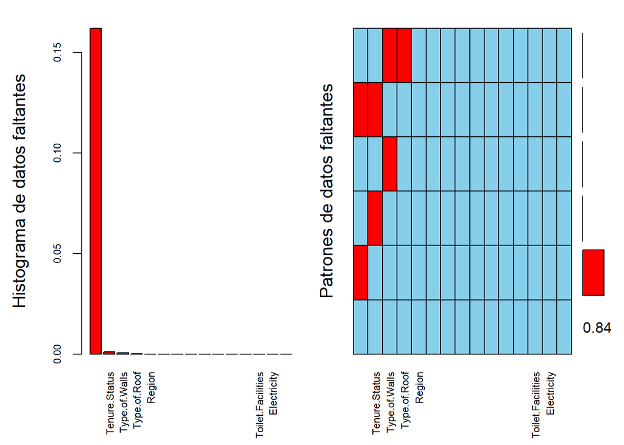

```
##
##  Variables sorted by number of missings:
##                                  Variable        Count
##            Household.Head.Class.of.Worker 0.1620573356
##                             Tenure.Status 0.0010118044
##                             Type.of.Walls 0.0006745363
##                              Type.of.Roof 0.0001686341
##                                    Region 0.0000000000
##                     Main.Source.of.Income 0.0000000000
##                        Household.Head.Sex 0.0000000000
##             Household.Head.Marital.Status 0.0000000000
##    Household.Head.Highest.Grade.Completed 0.0000000000
##  Household.Head.Job.or.Business.Indicator 0.0000000000
##                         Type.of.Household 0.0000000000
##                    Type.of.Building.House 0.0000000000
##                         Toilet.Facilities 0.0000000000
##                               Electricity 0.0000000000
##               Main.Source.of.Water.Supply 0.0000000000
```

```r
# Visualización gráfica de la distribución de NA en el conjunto de datos correspondiente a las variables cualitativas

aggr_plot<-aggr(var_train_cat
                ,numbers=TRUE,sortVars=TRUE,
                labels=names(var_train_cat)
                ,cex.axis=.7,gap=3
                ,ylab=c('Histograma de datos faltantes','Patrones de datos faltantes'),
                only.miss=TRUE)
```

```r
# Tabla de contingencias de las variables cuyos NA serán imputados

table_pre_Tenure<-prop.table(table(var_train_cat$Tenure.Status))
table_pre_Worker<-prop.table(table(var_train_cat$Household.Head.Class.of.Worker))
table_pre_Walls<-prop.table(table(var_train_cat$Type.of.Walls))
table_pre_Roof<-prop.table(table(var_train_cat$Type.of.Roof))

# Summary de las 4 variables cuyos NA serán imputados

summary_Tenure <- summary(var_train_cat$Tenure.Status)
summary_Worker <- summary(var_train_cat$Household.Head.Class.of.Worker)
summary_Walls<-summary(var_train_cat$Type.of.Walls)
summary_Roof<-summary(var_train_cat$Type.of.Roof)
```

Al decidir qué método de imputación de datos faltantes utilizar, es conveniente tener en cuenta que se está trabajando tratando con variables categóricas, y que el modelo a diseñar será una regresión lineal múltiple.

Por ello, una buena opción es el método no lineal KNN (k nearest neighbors), el cual calcula la distancia del elemento nuevo a cada uno de los existentes, y ordena dichas distancias de menor a mayor para ir seleccionando el grupo al que pertenece. Por lo tanto, dicho grupo será aquel que tenga una menor distacia con la mayor frecuencia.

```r
# Imputación de los valores NA usando el método no lineal kNN (k nearest neighbors)

var_train_cat <- VIM::kNN(var_train_cat,variable='Tenure.Status',impNA=TRUE)
var_train_cat$Tenure.Status_imp<-NULL
var_train_cat <- VIM::kNN(var_train_cat,variable='Household.Head.Class.of.Worker',impNA=TRUE)
var_train_cat$Household.Head.Class.of.Worker_imp<-NULL
var_train_cat <- VIM::kNN(var_train_cat,variable='Type.of.Walls',impNA=TRUE)
var_train_cat$Type.of.Walls_imp<-NULL
var_train_cat <- VIM::kNN(var_train_cat,variable='Type.of.Roof',impNA=TRUE)
var_train_cat$Type.of.Roof_imp<-NULL


# Comprobación de que se han eliminado todos los NA del conjunto de variables categóricas

length(which(is.na(var_train_cat)))
```

```
## [1] 0
```

```r
# Calculamos las tablas de contingencia tras haber imputado los NA con kNN

table_pos_Tenure<-prop.table(table(var_train_cat$Tenure.Status))
table_pos_Worker<-prop.table(table(var_train_cat$Household.Head.Class.of.Worker))
table_pos_Walls<-prop.table(table(var_train_cat$Type.of.Walls))
table_pos_Roof<-prop.table(table(var_train_cat$Type.of.Roof))
```

```r
# Comprobación de que las proporciones no se han visto afectadas por la imputación

porc_dif_Tenure <- (table_pos_Tenure*100)-(table_pre_Tenure*100)
porc_dif_Worker <- (table_pos_Worker*100)-(table_pre_Worker*100)
porc_dif_Walls <- (table_pos_Walls*100)-(table_pre_Walls*100)
porc_dif_Roof <- (table_pos_Roof*100)-(table_pre_Roof*100)
```

### 5.2 Transformación de variables

Para utilizar un modelo de regresión lineal múltiple, es muy conveniente que se cumplan las siquientes condiciones:

- Las variables tienen que tener distribución normal (en la medida de lo posible).
- Las variables no deben estar altamente correlacionadas entre sí.

Por lo tanto, para poder aplicar un modelo de regresión multiple a las variables numéricas del presente trabajo, es necesario plantear una transformación para que se acerquen lo más posible a una distribución normal. Se recuerda que durante el análisis eda, se constató que la mayoría de las variables mostraban un sesgo a la derecha, lo cual podría estropear el diseño del modelo (distribuciones no normales).

A continuación, se procede a aplicar una transformación a las variables: el logaritmo decimal. Se irán mostrando los histogramas de cada variable tras realizar la transformación, de manera que sea posible apreciar aquellas distribuciones que se han conseguido acercar a la distribución normal.

NOTA: todos los valores iguales a 0, cuya transformación resulta en -Infinito, han sido imputados a un valor 0, para no entorpecer la visualización.

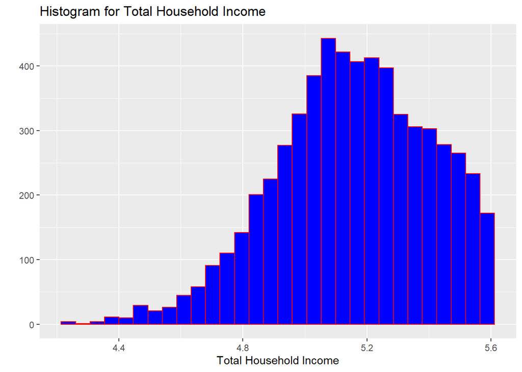

```r
# Transformación logarítmica, que produce que los valores iguales a 0 se transformen a -Inf (por la definición del logaritmo)

var_train_num_Log<- log10(var_train_num)

# Se imputan los valores -Infinito a valor 0, para no entorpecer la visualización y el procesado

Log_sin_inf <- replace(var_train_num_Log,var_train_num_Log=="-Inf",0)

# Histogramas de las variables cuantitativas transformadas con el logaritmo


qplot(Log_sin_inf[1:7000,1],
      geom="histogram",
      main = "Histogram for Total Household Income",
      xlab = "Total Household Income",
      fill=I("blue"),
      col=I("red"))
```

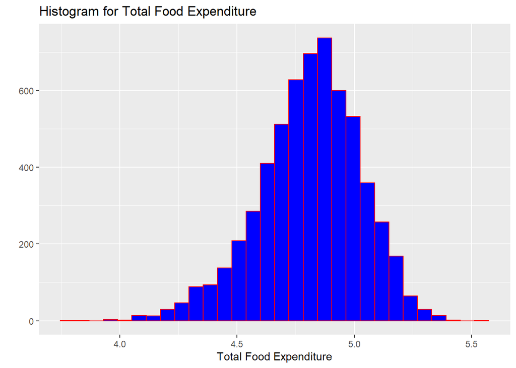

```r
qplot(Log_sin_inf[1:7000,2],
      geom="histogram",
      main = "Histogram for Total Food Expenditure",
      xlab = "Total Food Expenditure",
      fill=I("blue"),
      col=I("red"))
```

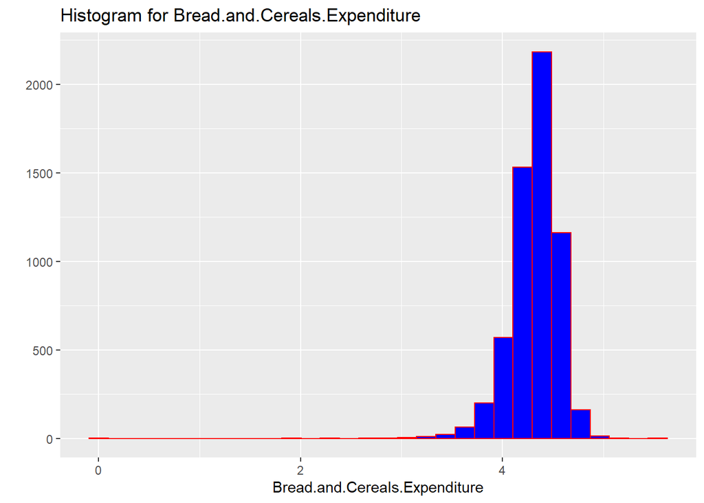

```r
qplot(Log_sin_inf[1:7000,3],
      geom="histogram",
      main = "Histogram for Bread.and.Cereals.Expenditure",
      xlab = "Bread.and.Cereals.Expenditure",
      fill=I("blue"),
      col=I("red"))
```

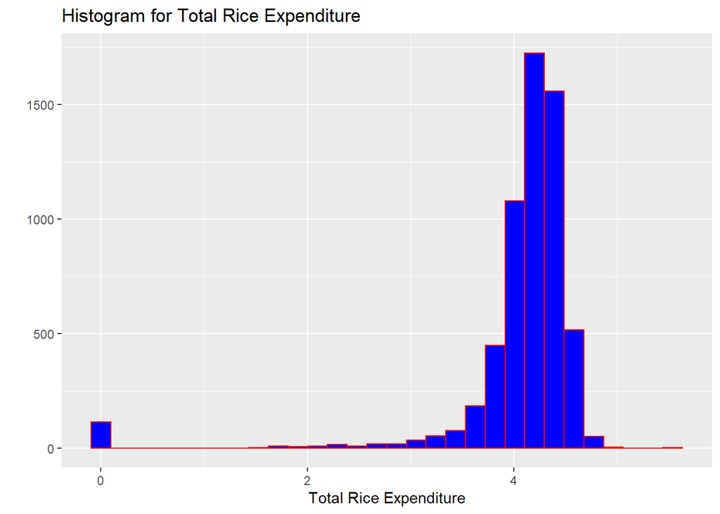

```r
qplot(Log_sin_inf[1:7000,4],
      geom="histogram",
      main = "Histogram for Total Rice Expenditure",
      xlab = "Total Rice Expenditure",
      fill=I("blue"),
      col=I("red"))
```

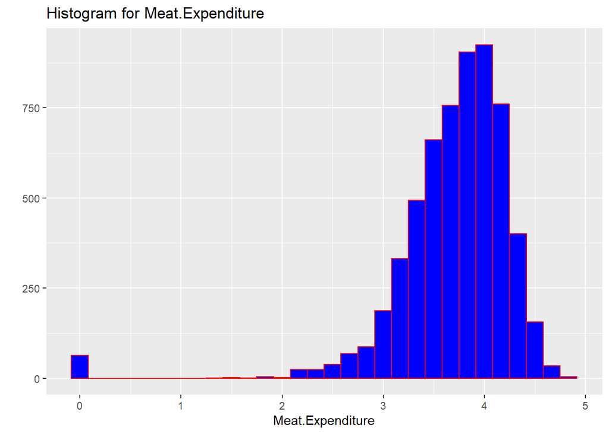

```r
qplot(Log_sin_inf[1:7000,5],
      geom="histogram",
      main = "Histogram for Meat.Expenditure",
      xlab = "Meat.Expenditure",
      fill=I("blue"),
      col=I("red"))
```

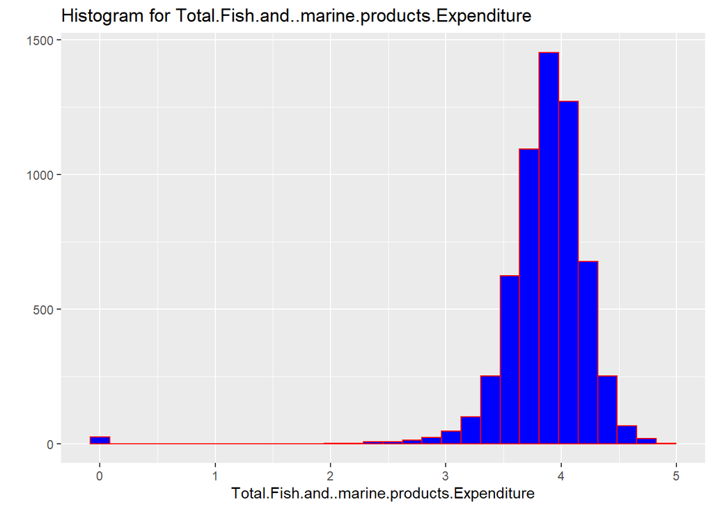

```r
qplot(Log_sin_inf[1:7000,6],
      geom="histogram",
      main = "Histogram for Total.Fish.and..marine.products.Expenditure",
      xlab = "Total.Fish.and..marine.products.Expenditure",
      fill=I("blue"),
      col=I("red"))
```

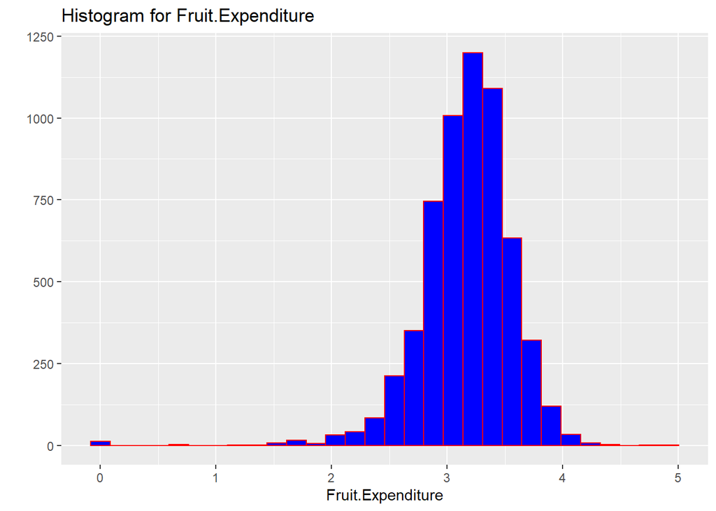

```r
qplot(Log_sin_inf[1:7000,7],
      geom="histogram",
      main = "Histogram for Fruit.Expenditure",
      xlab = "Fruit.Expenditure",
      fill=I("blue"),
      col=I("red"))
```

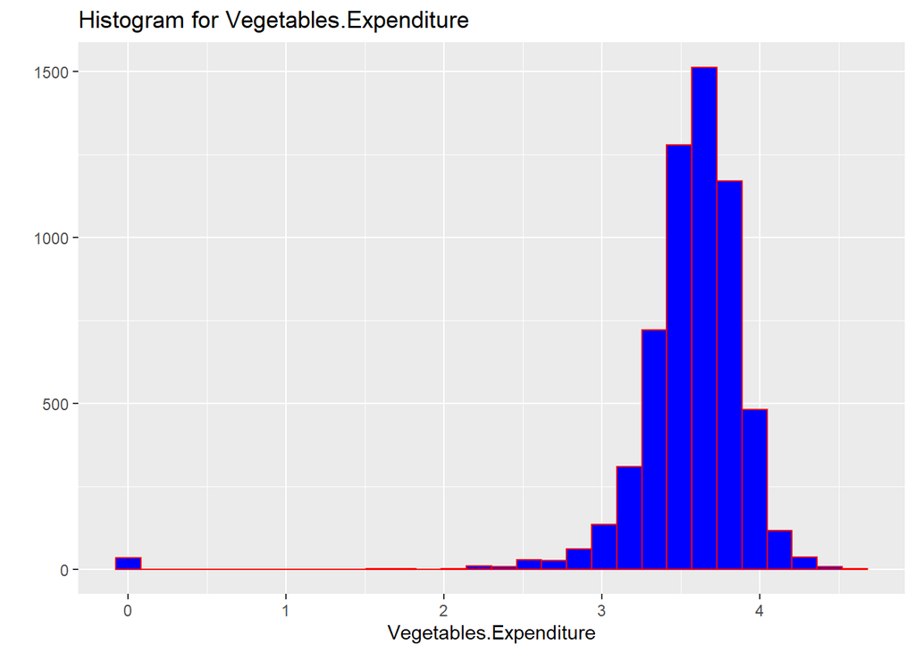

```r
qplot(Log_sin_inf[1:7000,8],
      geom="histogram",
      main = "Histogram for Vegetables.Expenditure",
      xlab = "Vegetables.Expenditure",
      fill=I("blue"),
      col=I("red"))
```

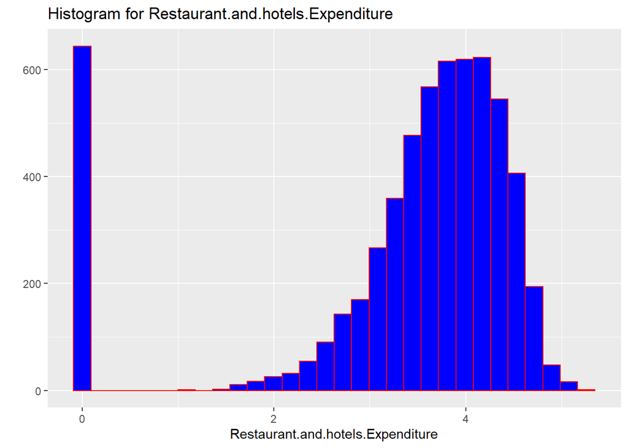

```r
qplot(Log_sin_inf[1:7000,9],
      geom="histogram",
      main = "Histogram for Restaurant.and.hotels.Expenditure",
      xlab = "Restaurant.and.hotels.Expenditure",
      fill=I("blue"),
      col=I("red"))
```

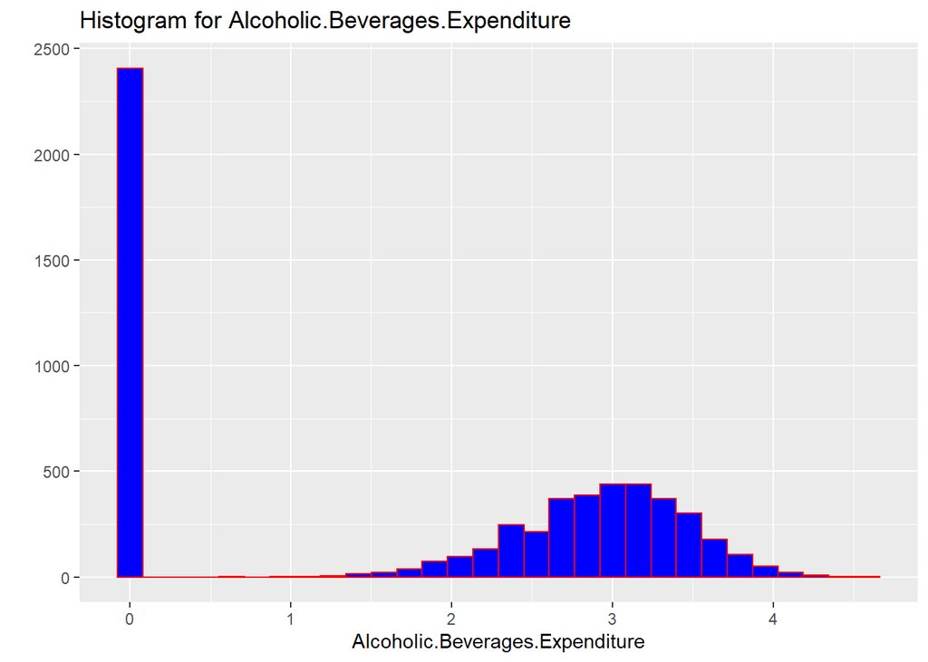

```r
qplot(Log_sin_inf[1:7000,10],
      geom="histogram",
      main = "Histogram for Alcoholic.Beverages.Expenditure",
      xlab = "Alcoholic.Beverages.Expenditure",
      fill=I("blue"),
      col=I("red"))
```

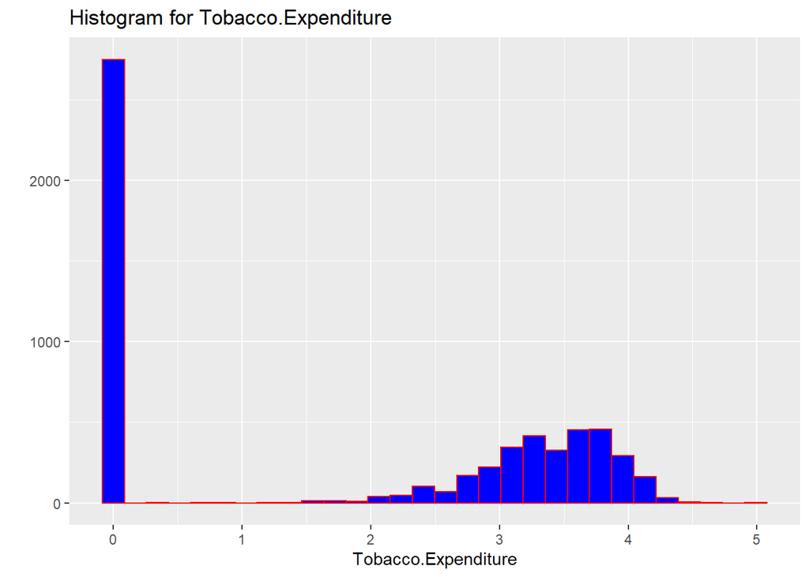

```r
qplot(Log_sin_inf[1:7000,11],
      geom="histogram",
      main = "Histogram for Tobacco.Expenditure",
      xlab = "Tobacco.Expenditure",
      fill=I("blue"),
      col=I("red"))
```